# Experiment 1B Plots

Sanne Poelstra

14/03/2021

# Preparing the data

```r
d <- read.csv("Experiment1_5.csv", header = TRUE, sep = ',')
#This is quite a lot so I want to trim it somewhat, e.g. things such as font are not needed
dat <- d[, c("A", "A1", "A1_alt", "A2", "A3", "A3_alt", "B", "B1", "B1_alt", "B2", "B3", "B3_alt", "X", "X1", "X1_alt", "X2", "X3", "X3_alt", "C", "C_alt", "Outcome", "Stim1", "Stim2", "responseR1", "responseR2", "responseR3",  "block1", "block2", "block3", "average_response_time", "avg_rt", "NewAnswers", "Practice", "date_starttime", "jatosStudyResultId", "pos1X", "pos1Y", "pos2X", "pos2Y", "prolific_id", "response_time", "Cond", "Train_Test", "screen_availableHeight", "screen_availableWidth",  "timeout_occurred", "total_response_time", "Trial")]

head(dat)
```

```
##                A        A1      A1_alt             A2          A3      A3_alt
## 1                Mouse.png Hamster.png Footprints.png Feather.png Peacock.png
## 2                Mouse.png Hamster.png Footprints.png Feather.png Peacock.png
## 3                Mouse.png Hamster.png Footprints.png Feather.png Peacock.png
## 4                Mouse.png Hamster.png Footprints.png Feather.png Peacock.png
## 5 Footprints.png Mouse.png Hamster.png Footprints.png Feather.png Peacock.png
## 6 Footprints.png Mouse.png Hamster.png Footprints.png Feather.png Peacock.png
##                  B         B1   B1_alt               B2      B3    B3_alt
## 1                  Flower.png Rose.png BlackBerries.png Log.png Stump.png
## 2                  Flower.png Rose.png BlackBerries.png Log.png Stump.png
## 3                  Flower.png Rose.png BlackBerries.png Log.png Stump.png
## 4                  Flower.png Rose.png BlackBerries.png Log.png Stump.png
## 5 BlackBerries.png Flower.png Rose.png BlackBerries.png Log.png Stump.png
## 6 BlackBerries.png Flower.png Rose.png BlackBerries.png Log.png Stump.png
##            X        X1       X1_alt         X2         X3      X3_alt
```

[output cut: 48 more lines]

```r
#now there were also some prolific IDs that were rejected, so I have to remove them
dat <- dat[which(dat$prolific_id != "5c055cbe4692a7000166a1f5" & dat$prolific_id != "602a79ad86b0770624288e16" & dat$prolific_id != "5f3ab64e0dda76127bcc344e" & dat$prolific_id != "5fe150610a5e7fbea05b7c92" & dat$prolific_id != "5db8b0df497a6e000afdf49a" & dat$prolific_id != "5f2b24c4224df7527baee383" & dat$prolific_id != "5f6b36e1ab9578230dd425df"),]
#5f6b36e1ab9578230dd425df is me

table(unique(dat$prolific_id)) #10 participants!
```

```
##
##                          5bc79f652885710001a0e82a 5cf9a6420a472100181f587b
##                        1                        1                        1
## 5ec7ec8d0125920a254a6cfa 5f578fcd87cb442352a8ac79 5f7236036a261413f61688df
##                        1                        1                        1
## 5ffa1ea174ea4b3b304bef6a 5ffc8a4990ccb70e106b02b0 60001fed22d8750008f1848c
##                        1                        1                        1
## 60021cc6d5be39201d34f6bf
##                        1
```

```r
table(dat$prolific_id) #one participant did less
```

```
##
##                          5bc79f652885710001a0e82a 5cf9a6420a472100181f587b
##                       87                       87                       87
## 5ec7ec8d0125920a254a6cfa 5f578fcd87cb442352a8ac79 5f7236036a261413f61688df
##                       87                       87                       87
## 5ffa1ea174ea4b3b304bef6a 5ffc8a4990ccb70e106b02b0 60001fed22d8750008f1848c
##                       86                       87                       87
## 60021cc6d5be39201d34f6bf
##                       87
```

```r
#As we don't know yet which condition was the first block, I'm going to have to assign a new column with that value
#blockNr depends on the value of block 1. If block 1 was 0 (internally 0 meant condition 0) and the condition of this current trial is 0, then we give this the value "block 1"

dat$blockNr <- ""
dat <- within(dat, blockNr[block1 == '0' & Cond == 0] <- 'Block1')
dat <- within(dat, blockNr[block1 == '1' & Cond == 50] <- 'Block1')
dat <- within(dat, blockNr[block1 == '2' & Cond == 100] <- 'Block1')
dat <- within(dat, blockNr[block2 == '0' & Cond == 0] <- 'Block2')
dat <- within(dat, blockNr[block2 == '1' & Cond == 50] <- 'Block2')
dat <- within(dat, blockNr[block2 == '2' & Cond == 100] <- 'Block2')
dat <- within(dat, blockNr[block3 == '0' & Cond == 0] <- 'Block3')
dat <- within(dat, blockNr[block3 == '1' & Cond == 50] <- 'Block3')
dat <- within(dat, blockNr[block3 == '2' & Cond == 100] <- 'Block3')

dat$CondFirstBlock <- ''
dat$CondSecondBlock <- ''
dat$CondThirdBlock <- ''

#dat$prolific_id <- as.factor(dat$prolific_id)

#to later compare the cues in the test phase to the condition they were originally asked in, we need another new column
#so for each participant, what condition was block 1? Save that in a row, what condition was block 3?
for(i in unique(dat$prolific_id)){
  dat <- within(dat, CondFirstBlock[prolific_id == i] <- Cond[prolific_id == i & blockNr == "Block1"])
  dat <- within(dat, CondSecondBlock[prolific_id == i] <- Cond[prolific_id == i & blockNr == "Block2"])
  dat <- within(dat, CondThirdBlock[prolific_id == i] <- Cond[prolific_id == i & blockNr == "Block3"])
} #HAAKJES
```

```r
#averages per condition, for X A and B
#responseR1 is always A, R2 is always B and R3 is always X

#train is the training phase. I want to make both a plot with 1's as answers removed, and one with all the answers, so I'll create two "train" dataframes
train1 <- dat[which(dat$Train_Test == "Train"),]
train <- dat[which(dat$Train_Test == "Train"),]

#Filter the 999 ones
train$responseR1[train$responseR1 == 999] <- NA
train$responseR2[train$responseR2 == 999] <- NA
train$responseR3[train$responseR3 == 999] <- NA

train1$responseR1[train1$responseR1 == 999] <- NA
train1$responseR2[train1$responseR2 == 999] <- NA
train1$responseR3[train1$responseR3 == 999] <- NA

train1$responseR1[train$responseR1 == 1] <- NA
train1$responseR2[train$responseR2 == 1] <- NA
train1$responseR3[train$responseR3 == 1] <- NA

train$Cond <- as.factor(train$Cond)
train$Cond <- factor(train$Cond, levels = c("0", "50", "100"))

train1$Cond <- as.factor(train1$Cond)
train1$Cond <- factor(train1$Cond, levels = c("0", "50", "100"))

a <- aggregate(list(train$responseR1, train$responseR2, train$responseR3), list(train$Cond), mean, na.rm = T)
b <- aggregate(list(train1$responseR1, train1$responseR2, train1$responseR3), list(train1$Cond), mean, na.rm = T)

colnames(a) <- c("Cond", "A", "B", "X")
colnames(b) <- c("Cond", "A", "B", "X")
head(a)
```

```
##   Cond        A        B        X
## 1    0 3.943750 3.391026 5.357143
## 2   50 4.446541 2.930380 5.331210
## 3  100 5.031250 3.150000 5.127389
```

```r
head(b)
```

```
##   Cond        A        B        X
## 1    0 5.617647 4.885417 5.692308
## 2   50 6.121495 4.546512 5.963504
## 3  100 6.286885 4.954023 5.729927
```

```r
SECondA <- c(std.error(train$responseR1[train$Cond == "0"]), std.error(train$responseR1[train$Cond == "50"]), std.error(train$responseR1[train$Cond == "100"]))
SECondB <- c(std.error(train$responseR2[train$Cond == "0"]), std.error(train$responseR2[train$Cond == "50"]), std.error(train$responseR2[train$Cond == "100"]))
SECondX <- c(std.error(train$responseR3[train$Cond == "0"]), std.error(train$responseR3[train$Cond == "50"]), std.error(train$responseR3[train$Cond == "100"]))

SECondA
```

```
## [1] 0.2352984 0.2507290 0.2361613
```

```r
SECondB
```

```
## [1] 0.2020519 0.1997977 0.2092965
```

```r
SECondX
```

```
## [1] 0.1979606 0.2152500 0.2194462
```

# Frequencies

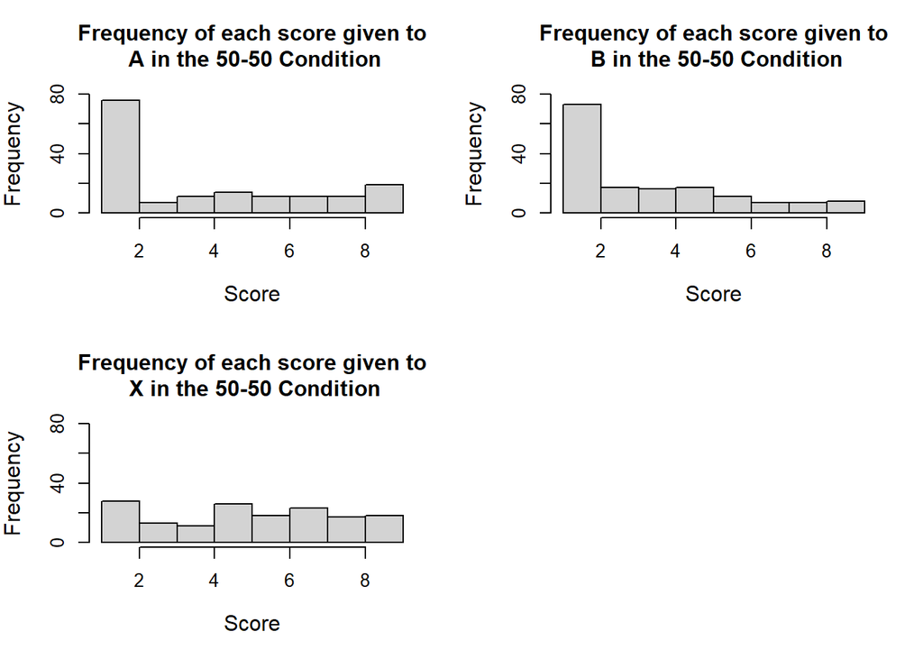

```r
par(mfrow = c(2,2))
hist(train$responseR1[train$Cond == "0"], breaks = 10, main = "Frequency of each score given to\n A in the 50-50 Condition", xlab = "Score", ylim = c(0,80), cex.lab = 1.2, cex.sub = 1.5)
hist(train$responseR2[train$Cond == "0"], breaks = 10, main = "Frequency of each score given to\n B in the 50-50 Condition", xlab = "Score", ylim = c(0,80), cex.lab = 1.2, cex.sub = 1.5)
hist(train$responseR3[train$Cond == "0"], breaks = 10, main = "Frequency of each score given to\n X in the 50-50 Condition", xlab = "Score", ylim = c(0,80), cex.lab = 1.2, cex.sub = 1.5)

par(mfrow = c(2,2))
```

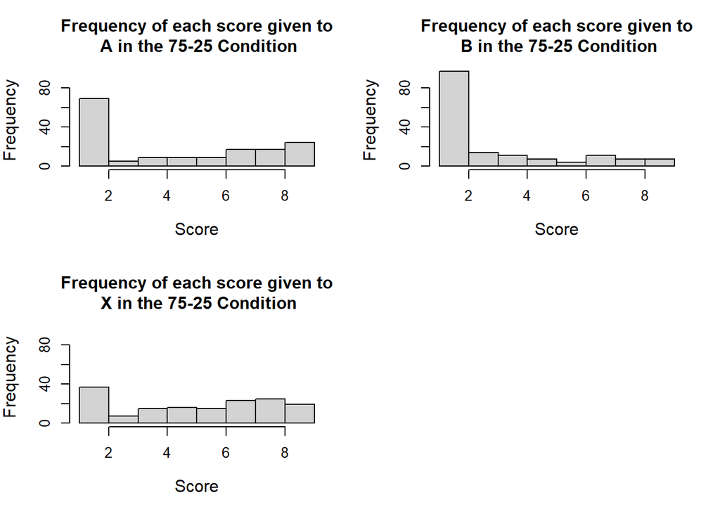

```r
hist(train$responseR1[train$Cond == "50"], breaks = 10, main = "Frequency of each score given to\n A in the 75-25 Condition", xlab = "Score", ylim = c(0,95), cex.lab = 1.2, cex.sub = 1.5)
hist(train$responseR2[train$Cond == "50"], breaks = 10, main = "Frequency of each score given to\n B in the 75-25 Condition", xlab = "Score", ylim = c(0,95), cex.lab = 1.2, cex.sub = 1.5)
hist(train$responseR3[train$Cond == "50"], breaks = 10, main = "Frequency of each score given to\n X in the 75-25 Condition", xlab = "Score", ylim = c(0,95), cex.lab = 1.2, cex.sub = 1.5)

par(mfrow = c(2,2))
```

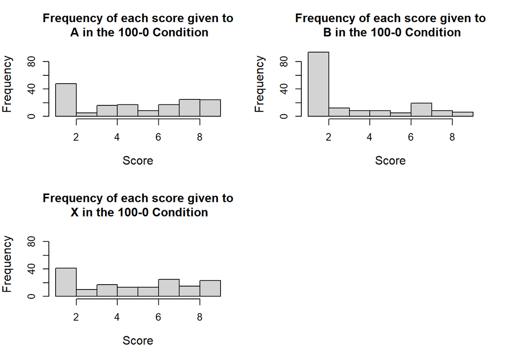

```r
hist(train$responseR1[train$Cond == "100"], breaks = 10, main = "Frequency of each score given to\n A in the 100-0 Condition", xlab = "Score", ylim = c(0,95), cex.lab = 1.2, cex.sub = 1.5)
hist(train$responseR2[train$Cond == "100"], breaks = 10, main = "Frequency of each score given to\n B in the 100-0 Condition", xlab = "Score", ylim = c(0,95), cex.lab = 1.2, cex.sub = 1.5)
hist(train$responseR3[train$Cond == "100"], breaks = 10, main = "Frequency of each score given to\n X in the 100-0 Condition", xlab = "Score", ylim = c(0,95), cex.lab = 1.2, cex.sub = 1.5)
```

```r
#As there are lots of 1's let's see how often people scored 1's on average for A B and X (over all conditions)

#Create a subset of data with just the 1's in there
OnesR1 <- subset(train, train$responseR1 == 1)
OnesR2 <- subset(train, train$responseR2 == 1)
OnesR3 <- subset(train, train$responseR3 == 1)
#Take the sum of these ones over participants (as we want to know how often (on average) one participant scored a 1 for A, B or X)
SumOnesR1 <- aggregate(OnesR1$responseR1, list(OnesR1$prolific_id), sum)
SumOnesR2 <- aggregate(OnesR2$responseR2, list(OnesR2$prolific_id), sum)
SumOnesR3 <- aggregate(OnesR3$responseR3, list(OnesR3$prolific_id), sum)
#then take the mean
AvgOnesR1 <- mean(SumOnesR1$x)
AvgOnesR2 <- mean(SumOnesR2$x)
AvgOnesR3 <- mean(SumOnesR3$x)
AvgOnesR1
```

```
## [1] 16.44444
```

```r
AvgOnesR2
```

```
## [1] 22.77778
```

```r
AvgOnesR3
```

```
## [1] 5.666667
```

The average amount of 1’s given to A is 16, which is 33.3% of all trails, and 4 higher than in the original experiment.  
The average amount of 1’s given to B is 23, which is 47,9% of all trials, and is 7 higher than in the original experiment.  
And the average amount of 1’s given to X is 6, which is 12.5% of all trials, and is 1 lower than the original experiment.  
You would expect that B is scored lower over all (as it’s the least predictive over all), and A to be scored higher over all, so have less 1’s than the rest. However what we see here is that X, the stimuli that always appears is actually scored 1 the least amount of times.

```r
#over the 16 trials, for each of the conditions, get the average response for A, B and X
AllTrials <- aggregate(list(train$responseR1, train$responseR2, train$responseR3), list(train$Cond, train$Trial), mean, na.rm = T)
AllTrials1 <- aggregate(list(train1$responseR1, train1$responseR2, train1$responseR3), list(train1$Cond, train1$Trial), mean, na.rm = T)
colnames(AllTrials) <- c("Cond", "Trial", "A", "B", "X")
colnames(AllTrials1) <- c("Cond", "Trial", "A", "B", "X")

#Then split this into the different conditions
Cond000 <- AllTrials[which(AllTrials$Cond==0),]
Cond050 <- AllTrials[which(AllTrials$Cond==50),]
Cond100 <- AllTrials[which(AllTrials$Cond==100),]

#This is then the one without 1's
Cond0001 <- AllTrials1[which(AllTrials1$Cond==0),]
Cond0501 <- AllTrials1[which(AllTrials1$Cond==50),]
Cond1001 <- AllTrials1[which(AllTrials1$Cond==100),]

SETrials000A <- c(std.error(train$responseR1[train$Cond == "0" & train$Trial == '1']), std.error(train$responseR1[train$Cond == "0" & train$Trial == '2']), std.error(train$responseR1[train$Cond == "0" & train$Trial == '3']), std.error(train$responseR1[train$Cond == "0" & train$Trial == '4']), std.error(train$responseR1[train$Cond == "0" & train$Trial == '5']), std.error(train$responseR1[train$Cond == "0" & train$Trial == '6']), std.error(train$responseR1[train$Cond == "0" & train$Trial == '7']), std.error(train$responseR1[train$Cond == "0" & train$Trial == '8']), std.error(train$responseR1[train$Cond == "0" & train$Trial == '9']), std.error(train$responseR1[train$Cond == "0" & train$Trial == '10']), std.error(train$responseR1[train$Cond == "0" & train$Trial == '11']), std.error(train$responseR1[train$Cond == "0" & train$Trial == '12']), std.error(train$responseR1[train$Cond == "0" & train$Trial == '13']), std.error(train$responseR1[train$Cond == "0" & train$Trial == '14']), std.error(train$responseR1[train$Cond == "0" & train$Trial == '15']), std.error(train$responseR1[train$Cond == "0" & train$Trial == '16']))
SETrials000B <- c(std.error(train$responseR2[train$Cond == "0" & train$Trial == '1']), std.error(train$responseR2[train$Cond == "0" & train$Trial == '2']), std.error(train$responseR2[train$Cond == "0" & train$Trial == '3']), std.error(train$responseR2[train$Cond == "0" & train$Trial == '4']), std.error(train$responseR2[train$Cond == "0" & train$Trial == '5']), std.error(train$responseR2[train$Cond == "0" & train$Trial == '6']), std.error(train$responseR2[train$Cond == "0" & train$Trial == '7']), std.error(train$responseR2[train$Cond == "0" & train$Trial == '8']), std.error(train$responseR2[train$Cond == "0" & train$Trial == '9']), std.error(train$responseR2[train$Cond == "0" & train$Trial == '10']), std.error(train$responseR2[train$Cond == "0" & train$Trial == '11']), std.error(train$responseR2[train$Cond == "0" & train$Trial == '12']), std.error(train$responseR2[train$Cond == "0" & train$Trial == '13']), std.error(train$responseR2[train$Cond == "0" & train$Trial == '14']), std.error(train$responseR2[train$Cond == "0" & train$Trial == '15']), std.error(train$responseR2[train$Cond == "0" & train$Trial == '16']))
SETrials000X <- c(std.error(train$responseR3[train$Cond == "0" & train$Trial == '1']), std.error(train$responseR3[train$Cond == "0" & train$Trial == '2']), std.error(train$responseR3[train$Cond == "0" & train$Trial == '3']), std.error(train$responseR3[train$Cond == "0" & train$Trial == '4']), std.error(train$responseR3[train$Cond == "0" & train$Trial == '5']), std.error(train$responseR3[train$Cond == "0" & train$Trial == '6']), std.error(train$responseR3[train$Cond == "0" & train$Trial == '7']), std.error(train$responseR3[train$Cond == "0" & train$Trial == '8']), std.error(train$responseR3[train$Cond == "0" & train$Trial == '9']), std.error(train$responseR3[train$Cond == "0" & train$Trial == '10']), std.error(train$responseR3[train$Cond == "0" & train$Trial == '11']), std.error(train$responseR3[train$Cond == "0" & train$Trial == '12']), std.error(train$responseR3[train$Cond == "0" & train$Trial == '13']), std.error(train$responseR3[train$Cond == "0" & train$Trial == '14']), std.error(train$responseR3[train$Cond == "0" & train$Trial == '15']), std.error(train$responseR3[train$Cond == "0" & train$Trial == '16']))


SETrials050A <- c(std.error(train$responseR1[train$Cond == "50" & train$Trial == '1']), std.error(train$responseR1[train$Cond == "50" & train$Trial == '2']), std.error(train$responseR1[train$Cond == "50" & train$Trial == '3']), std.error(train$responseR1[train$Cond == "50" & train$Trial == '4']), std.error(train$responseR1[train$Cond == "50" & train$Trial == '5']), std.error(train$responseR1[train$Cond == "50" & train$Trial == '6']), std.error(train$responseR1[train$Cond == "50" & train$Trial == '7']), std.error(train$responseR1[train$Cond == "50" & train$Trial == '8']), std.error(train$responseR1[train$Cond == "50" & train$Trial == '9']), std.error(train$responseR1[train$Cond == "50" & train$Trial == '10']), std.error(train$responseR1[train$Cond == "50" & train$Trial == '11']), std.error(train$responseR1[train$Cond == "50" & train$Trial == '12']), std.error(train$responseR1[train$Cond == "50" & train$Trial == '13']), std.error(train$responseR1[train$Cond == "50" & train$Trial == '14']), std.error(train$responseR1[train$Cond == "50" & train$Trial == '15']), std.error(train$responseR1[train$Cond == "50" & train$Trial == '16']))
SETrials050B <- c(std.error(train$responseR2[train$Cond == "50" & train$Trial == '1']), std.error(train$responseR2[train$Cond == "50" & train$Trial == '2']), std.error(train$responseR2[train$Cond == "50" & train$Trial == '3']), std.error(train$responseR2[train$Cond == "50" & train$Trial == '4']), std.error(train$responseR2[train$Cond == "50" & train$Trial == '5']), std.error(train$responseR2[train$Cond == "50" & train$Trial == '6']), std.error(train$responseR2[train$Cond == "50" & train$Trial == '7']), std.error(train$responseR2[train$Cond == "50" & train$Trial == '8']), std.error(train$responseR2[train$Cond == "50" & train$Trial == '9']), std.error(train$responseR2[train$Cond == "50" & train$Trial == '10']), std.error(train$responseR2[train$Cond == "50" & train$Trial == '11']), std.error(train$responseR2[train$Cond == "50" & train$Trial == '12']), std.error(train$responseR2[train$Cond == "50" & train$Trial == '13']), std.error(train$responseR2[train$Cond == "50" & train$Trial == '14']), std.error(train$responseR2[train$Cond == "50" & train$Trial == '15']), std.error(train$responseR2[train$Cond == "50" & train$Trial == '16']))
SETrials050X <- c(std.error(train$responseR3[train$Cond == "50" & train$Trial == '1']), std.error(train$responseR3[train$Cond == "50" & train$Trial == '2']), std.error(train$responseR3[train$Cond == "50" & train$Trial == '3']), std.error(train$responseR3[train$Cond == "50" & train$Trial == '4']), std.error(train$responseR3[train$Cond == "50" & train$Trial == '5']), std.error(train$responseR3[train$Cond == "50" & train$Trial == '6']), std.error(train$responseR3[train$Cond == "50" & train$Trial == '7']), std.error(train$responseR3[train$Cond == "50" & train$Trial == '8']), std.error(train$responseR3[train$Cond == "50" & train$Trial == '9']), std.error(train$responseR3[train$Cond == "50" & train$Trial == '10']), std.error(train$responseR3[train$Cond == "50" & train$Trial == '11']), std.error(train$responseR3[train$Cond == "50" & train$Trial == '12']), std.error(train$responseR3[train$Cond == "50" & train$Trial == '13']), std.error(train$responseR3[train$Cond == "50" & train$Trial == '14']), std.error(train$responseR3[train$Cond == "50" & train$Trial == '15']), std.error(train$responseR3[train$Cond == "50" & train$Trial == '16']))

SETrials100A <- c(std.error(train$responseR1[train$Cond == "100" & train$Trial == '1']), std.error(train$responseR1[train$Cond == "100" & train$Trial == '2']), std.error(train$responseR1[train$Cond == "100" & train$Trial == '3']), std.error(train$responseR1[train$Cond == "100" & train$Trial == '4']), std.error(train$responseR1[train$Cond == "100" & train$Trial == '5']), std.error(train$responseR1[train$Cond == "100" & train$Trial == '6']), std.error(train$responseR1[train$Cond == "100" & train$Trial == '7']), std.error(train$responseR1[train$Cond == "100" & train$Trial == '8']), std.error(train$responseR1[train$Cond == "100" & train$Trial == '9']), std.error(train$responseR1[train$Cond == "100" & train$Trial == '10']), std.error(train$responseR1[train$Cond == "100" & train$Trial == '11']), std.error(train$responseR1[train$Cond == "100" & train$Trial == '12']), std.error(train$responseR1[train$Cond == "100" & train$Trial == '13']), std.error(train$responseR1[train$Cond == "100" & train$Trial == '14']), std.error(train$responseR1[train$Cond == "100" & train$Trial == '15']), std.error(train$responseR1[train$Cond == "100" & train$Trial == '16']))
SETrials100B <- c(std.error(train$responseR2[train$Cond == "100" & train$Trial == '1']), std.error(train$responseR2[train$Cond == "100" & train$Trial == '2']), std.error(train$responseR2[train$Cond == "100" & train$Trial == '3']), std.error(train$responseR2[train$Cond == "100" & train$Trial == '4']), std.error(train$responseR2[train$Cond == "100" & train$Trial == '5']), std.error(train$responseR2[train$Cond == "100" & train$Trial == '6']), std.error(train$responseR2[train$Cond == "100" & train$Trial == '7']), std.error(train$responseR2[train$Cond == "100" & train$Trial == '8']), std.error(train$responseR2[train$Cond == "100" & train$Trial == '9']), std.error(train$responseR2[train$Cond == "100" & train$Trial == '10']), std.error(train$responseR2[train$Cond == "100" & train$Trial == '11']), std.error(train$responseR2[train$Cond == "100" & train$Trial == '12']), std.error(train$responseR2[train$Cond == "100" & train$Trial == '13']), std.error(train$responseR2[train$Cond == "100" & train$Trial == '14']), std.error(train$responseR2[train$Cond == "100" & train$Trial == '15']), std.error(train$responseR2[train$Cond == "100" & train$Trial == '16']))
SETrials100X <- c(std.error(train$responseR3[train$Cond == "100" & train$Trial == '1']), std.error(train$responseR3[train$Cond == "100" & train$Trial == '2']), std.error(train$responseR3[train$Cond == "100" & train$Trial == '3']), std.error(train$responseR3[train$Cond == "100" & train$Trial == '4']), std.error(train$responseR3[train$Cond == "100" & train$Trial == '5']), std.error(train$responseR3[train$Cond == "100" & train$Trial == '6']), std.error(train$responseR3[train$Cond == "100" & train$Trial == '7']), std.error(train$responseR3[train$Cond == "100" & train$Trial == '8']), std.error(train$responseR3[train$Cond == "100" & train$Trial == '9']), std.error(train$responseR3[train$Cond == "100" & train$Trial == '10']), std.error(train$responseR3[train$Cond == "100" & train$Trial == '11']), std.error(train$responseR3[train$Cond == "100" & train$Trial == '12']), std.error(train$responseR3[train$Cond == "100" & train$Trial == '13']), std.error(train$responseR3[train$Cond == "100" & train$Trial == '14']), std.error(train$responseR3[train$Cond == "100" & train$Trial == '15']), std.error(train$responseR3[train$Cond == "100" & train$Trial == '16']))


SETrials000A
```

```
##  [1] 0.7118052 0.6155395 0.8491826 0.9092121 0.8439326 1.0225241 0.8359957
##  [8] 0.9910712 0.8137704 0.8406347 1.0624918 0.7023769 0.7156970 0.8326664
## [15] 0.6831301 1.0796090
```

```r
SETrials000B
```

```
##  [1] 0.2421611 0.7453560 0.5773503 0.6155395 0.8624541 0.8825468 0.7156970
##  [8] 0.8406347 0.7916228 0.5467073 0.7483315 0.6046119 0.4818944 0.8537499
## [15] 0.8192137 0.6871843
```

```r
SETrials000X
```

```
##  [1] 1.0690450 0.7310571 0.8164966 0.8055364 0.5957670 0.6699917 0.5426274
##  [8] 0.8888889 0.9315459 0.9428090 0.7745967 0.7461010 0.5537749 0.7423686
## [15] 0.7272475 0.6009252
```

```r
#A LOT higher (almost double of Exp 1). With def more variation (1! but also 0.6)


SETrials050A
```

```
##  [1] 0.7666667 0.8306624 0.1632993 0.7753136 0.8062258 1.1160446 0.8569973
##  [8] 1.2382784 0.8192137 0.7951240 1.1152700 0.6863753 1.0159834 1.1527744
## [15] 0.3785939 1.2292726
```

```r
SETrials050B
```

```
##  [1] 0.4582576 0.7717225 0.9597453 0.6741249 0.7180220 0.8439326 0.5962848
##  [8] 0.8844333 0.7218803 0.7718024 0.7895146 0.8836652 0.7895146 0.7453560
## [15] 0.7951240 0.8749603
```

```r
SETrials050X
```

```
##  [1] 0.6155395 0.7608475 0.8034647 0.7310571 0.9333333 0.8919392 0.5773503
##  [8] 0.7859884 0.6406979 0.7371115 0.8749603 0.4268749 0.9243616 0.9451631
## [15] 0.5925463 1.0801234
```

```r
#Same here, also when compared to 000


SETrials100A
```

```
##  [1] 0.8333333 0.9797959 1.0022198 0.9752493 0.9043107 0.8825468 0.5925463
##  [8] 0.9457507 0.9363048 0.9213517 0.9666667 0.8975275 0.9977753 0.9315459
## [15] 0.9000000 1.0796090
```

```r
SETrials100B
```

```
##  [1] 0.6110101 0.4818944 0.7423686 0.5587685 0.7180220 1.0376255 0.8875685
##  [8] 0.8273116 0.8465617 1.0440307 0.9826269 0.8306624 1.0349450 0.9451631
## [15] 0.9803627 0.8306624
```

```r
SETrials100X
```

```
##  [1] 0.7500000 0.7027284 0.9189366 0.7717225 0.8692270 0.9666667 0.3349959
##  [8] 0.6333333 0.7895146 0.8198916 0.8089774 0.7520343 0.8027730 1.1372481
## [15] 0.6227181 0.9333333
```

```r
#Same heren
```

Here too, the values in Cond000, Cond050 and Cond100 differ ever so slightly from the averages in a (the one that is used to plot the plot below). This could be due to rounding errors (as here we first aggregate over trial as well instead of just fully over condition). But it’s important to note!

# Averages

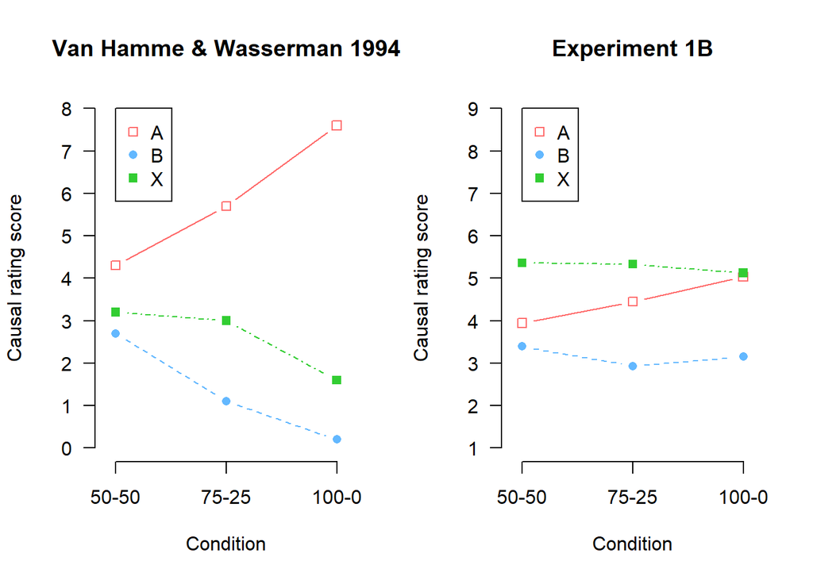

```r
par(mfrow = c(1,2))
par(las=1)
#original plot
emptyPlot(c(-5,105),c(0,8), xaxt = "none", ymark=c(0,1,2,3,4,5,6,7,8), bty='n', main = "Van Hamme & Wasserman 1994", xlab = "Condition", ylab = "Causal rating score")
A <- c(4.3,5.7,7.6)
B <- c(2.7, 1.1, 0.2)
X <- c(3.2,3,1.6)
points(c(0, 50, 100),A, pch = 0, type = "b", col = "indianred1")
points(c(0, 50, 100),B, pch =16, type = "b", lty = 2, col = "steelblue1")
points(c(0, 50, 100),X, pch =15, type = "b", lty = 4, col = "limegreen")
legend(0.05,8,legend =c("A", "B", "X"), pch = c(0,16,15), col = c("indianred1", "steelblue1", "limegreen"))
axis(1, at = c(0,50,100), labels = c("50-50", "75-25", "100-0"))

#Our experiment
emptyPlot(c(-5,105),c(1,9), xaxt = "none", ymark=c(1,2,3,4,5,6,7,8,9), bty='n', main = "Experiment 1B", xlab = "Condition", ylab = "Causal rating score")
A <- c(a$A)
B <- c(a$B)
X <- c(a$X)
points(c(0, 50, 100),A, pch = 0, type = "b", col = "indianred1")
points(c(0, 50, 100),B, pch =16, type = "b", lty = 2, col = "steelblue1")
points(c(0, 50, 100),X, pch =15, type = "b", lty = 4, col = "limegreen")
legend(0.05,9,legend =c("A", "B", "X"), pch = c(0,16,15), col = c("indianred1", "steelblue1", "limegreen"))
axis(1, at = c(0,50,100), labels = c("50-50", "75-25", "100-0"))
```

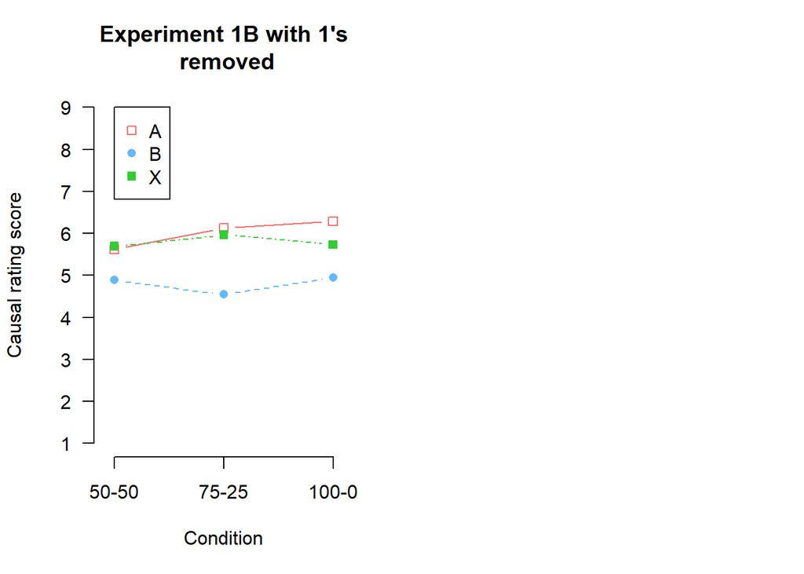

```r
#Our experiment with 1's removed
emptyPlot(c(-5,105),c(1,9), xaxt = "none", ymark=c(1,2,3,4,5,6,7,8,9), bty='n', main = "Experiment 1B with 1's\n removed", xlab = "Condition", ylab = "Causal rating score")
A <- c(b$A)
B <- c(b$B)
X <- c(b$X)
points(c(0, 50, 100),A, pch = 0, type = "b", col = "indianred1")
points(c(0, 50, 100),B, pch =16, type = "b", lty = 2, col = "steelblue1")
points(c(0, 50, 100),X, pch =15, type = "b", lty = 4, col = "limegreen")
legend(0.05,9,legend =c("A", "B", "X"), pch = c(0,16,15), col = c("indianred1", "steelblue1", "limegreen"))
axis(1, at = c(0,50,100), labels = c("50-50", "75-25", "100-0"))
```

## Averages Thicker lines

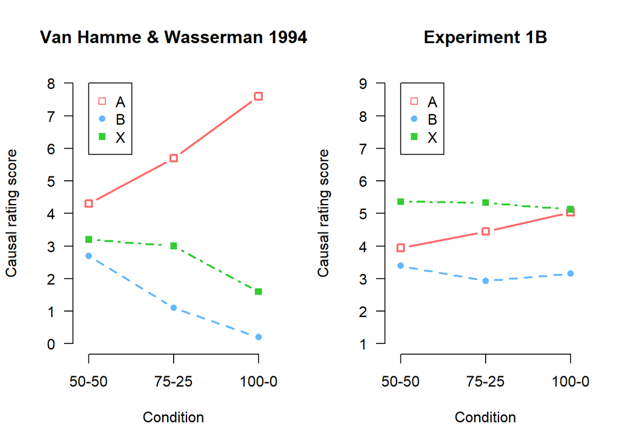

```r
par(mfrow = c(1,2))
par(las=1)
#original plot
emptyPlot(c(-5,105),c(0,8), xaxt = "none", ymark=c(0,1,2,3,4,5,6,7,8), bty='n', main = "Van Hamme & Wasserman 1994", xlab = "Condition", ylab = "Causal rating score")
A <- c(4.3,5.7,7.6)
B <- c(2.7, 1.1, 0.2)
X <- c(3.2,3,1.6)
points(c(0, 50, 100),A, pch = 0, type = "b", col = "indianred1", lwd = 2)
points(c(0, 50, 100),B, pch =16, type = "b", lty = 2, col = "steelblue1", lwd = 2)
points(c(0, 50, 100),X, pch =15, type = "b", lty = 4, col = "limegreen", lwd = 2)
legend(0.05,8,legend =c("A", "B", "X"), pch = c(0,16,15), col = c("indianred1", "steelblue1", "limegreen"))
axis(1, at = c(0,50,100), labels = c("50-50", "75-25", "100-0"))

#Our experiment
emptyPlot(c(-5,105),c(1,9), xaxt = "none", ymark=c(1,2,3,4,5,6,7,8,9), bty='n', main = "Experiment 1B", xlab = "Condition", ylab = "Causal rating score")
A <- c(a$A)
B <- c(a$B)
X <- c(a$X)
points(c(0, 50, 100),A, pch = 0, type = "b", col = "indianred1", lwd =2 )
points(c(0, 50, 100),B, pch =16, type = "b", lty = 2, col = "steelblue1", lwd =2)
points(c(0, 50, 100),X, pch =15, type = "b", lty = 4, col = "limegreen", lwd = 2)
legend(0.05,9,legend =c("A", "B", "X"), pch = c(0,16,15), col = c("indianred1", "steelblue1", "limegreen"))
axis(1, at = c(0,50,100), labels = c("50-50", "75-25", "100-0"))
```

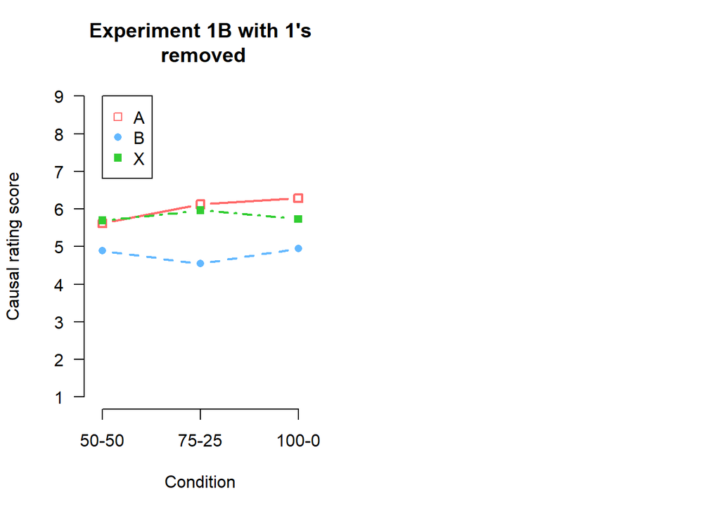

```r
#Our experiment with 1's removed
emptyPlot(c(-5,105),c(1,9), xaxt = "none", ymark=c(1,2,3,4,5,6,7,8,9), bty='n', main = "Experiment 1B with 1's\n removed", xlab = "Condition", ylab = "Causal rating score")
A <- c(b$A)
B <- c(b$B)
X <- c(b$X)
points(c(0, 50, 100),A, pch = 0, type = "b", col = "indianred1", lwd = 2)
points(c(0, 50, 100),B, pch =16, type = "b", lty = 2, col = "steelblue1", lwd =2)
points(c(0, 50, 100),X, pch =15, type = "b", lty = 4, col = "limegreen", lwd =2)
legend(0.05,9,legend =c("A", "B", "X"), pch = c(0,16,15), col = c("indianred1", "steelblue1", "limegreen"))
axis(1, at = c(0,50,100), labels = c("50-50", "75-25", "100-0"))
```

## Averages SE

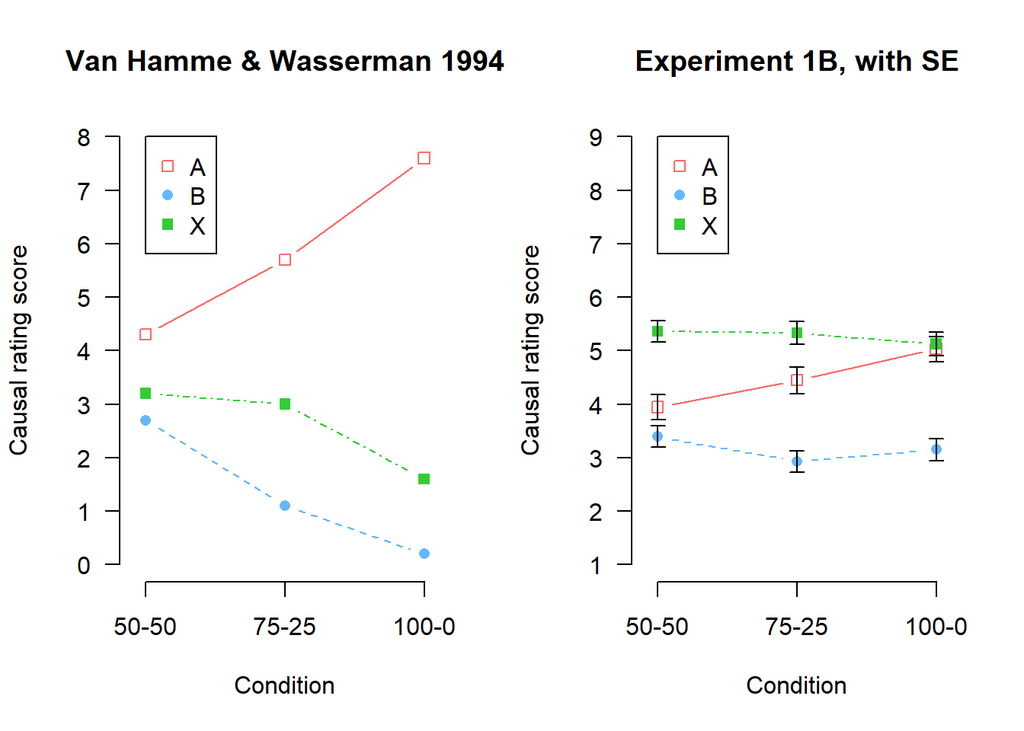

```r
par(mfrow = c(1,2))
par(las=1)
#original plot
emptyPlot(c(-5,105),c(0,8), xaxt = "none", ymark=c(0,1,2,3,4,5,6,7,8), bty='n', main = "Van Hamme & Wasserman 1994", xlab = "Condition", ylab = "Causal rating score")
A <- c(4.3,5.7,7.6)
B <- c(2.7, 1.1, 0.2)
X <- c(3.2,3,1.6)
points(c(0, 50, 100),A, pch = 0, type = "b", col = "indianred1")
points(c(0, 50, 100),B, pch =16, type = "b", lty = 2, col = "steelblue1")
points(c(0, 50, 100),X, pch =15, type = "b", lty = 4, col = "limegreen")
legend(0.05,8,legend =c("A", "B", "X"), pch = c(0,16,15), col = c("indianred1", "steelblue1", "limegreen"))
axis(1, at = c(0,50,100), labels = c("50-50", "75-25", "100-0"))

#Our experiment
emptyPlot(c(-5,105),c(1,9), xaxt = "none", ymark=c(1,2,3,4,5,6,7,8,9), bty='n', main = "Experiment 1B, with SE", xlab = "Condition", ylab = "Causal rating score")
A <- c(a$A)
B <- c(a$B)
X <- c(a$X)
points(c(0, 50, 100),A, pch = 0, type = "b", col = "indianred1")
points(c(0, 50, 100),B, pch =16, type = "b", lty = 2, col = "steelblue1")
points(c(0, 50, 100),X, pch =15, type = "b", lty = 4, col = "limegreen")
errorbars(x= c(0,50,100), y = a$A, top = SECondA, bottom = SECondA, add = TRUE, length = 0.05)
errorbars(x= c(0,50,100), y = a$B, top = SECondB, bottom = SECondB, add = TRUE, length = 0.05)
errorbars(x= c(0,50,100), y = a$X, top = SECondX, bottom = SECondX, add = TRUE, length = 0.05)
legend(0.05,9,legend =c("A", "B", "X"), pch = c(0,16,15), col = c("indianred1", "steelblue1", "limegreen"))
axis(1, at = c(0,50,100), labels = c("50-50", "75-25", "100-0"))
```

def bigger SE than in the first experiment

## Cond 000

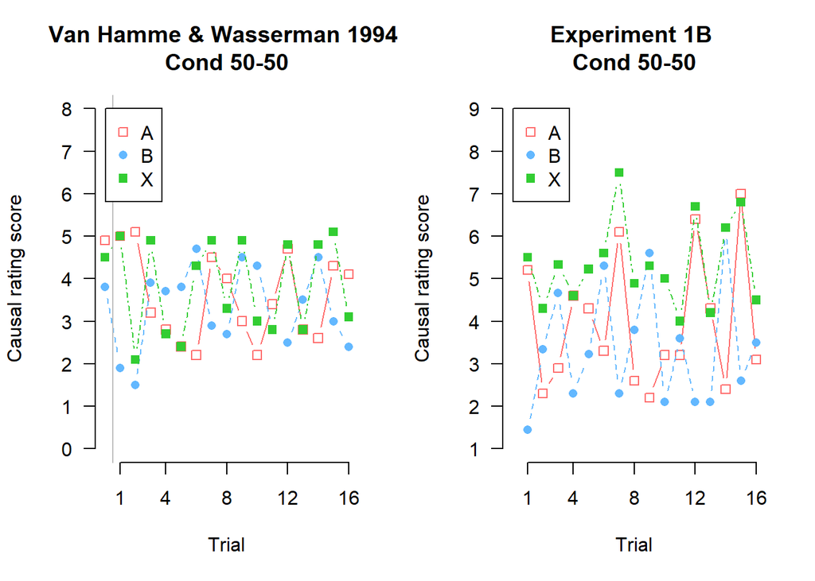

```r
par(mfrow = c(1,2))
par(las=1)
#original plot
emptyPlot(c(0,16),c(0,8), xmark = c(1,4,8,12,16), ymark=c(0,1,2,3,4,5,6,7,8), bty='n', main = "Van Hamme & Wasserman 1994 \nCond 50-50", xlab = "Trial", ylab = "Causal rating score")
A <- c(4.9, 5, 5.1, 3.2, 2.8, 2.4, 2.2, 4.5, 4, 3, 2.2, 3.4, 4.7, 2.8, 2.6, 4.3, 4.1)
B <- c(3.8, 1.9, 1.5, 3.9, 3.7, 3.8, 4.7, 2.9, 2.7, 4.5, 4.3, 2.8, 2.5, 3.5, 4.5, 3, 2.4)
X <- c(4.5, 5, 2.1, 4.9, 2.7, 2.4, 4.3, 4.9, 3.3, 4.9, 3, 2.8, 4.8,2.8, 4.8, 5.1, 3.1)
points(c(0:16),A, pch = 0, type = "b", col = "indianred1")
points(c(0:16),B, pch =16, type = "b", lty = 2, col = "steelblue1")
points(c(0:16),X, pch =15, type = "b", lty = 4, col = "limegreen")
abline(v=0.5, col="grey", lty = 1)
legend(0.05,8,legend =c("A", "B", "X"), pch = c(0,16,15), col = c("indianred1", "steelblue1", "limegreen"))

emptyPlot(c(0,16),c(1,9), xmark = c(1,4,8,12,16), ymark=c(1,2,3,4,5,6,7,8, 9), bty='n', main = "Experiment 1B \nCond 50-50", xlab = "Trial", ylab = "Causal rating score")
A <- Cond000$A
B <- Cond000$B
X <- Cond000$X
points(c(1:16),A, pch = 0, type = "b", col = "indianred1")
points(c(1:16),B, pch =16, type = "b", lty = 2, col = "steelblue1")
points(c(1:16),X, pch =15, type = "b", lty = 4, col = "limegreen")
legend(0.05,9,legend =c("A", "B", "X"), pch = c(0,16,15), col = c("indianred1", "steelblue1", "limegreen"))
```

## Cond 000 Thicker lines

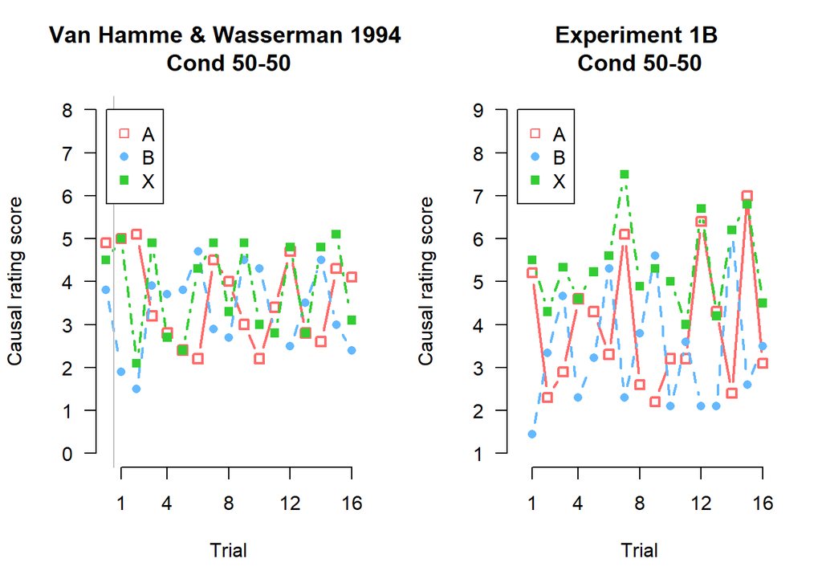

```r
par(mfrow = c(1,2))
par(las=1)
#original plot
emptyPlot(c(0,16),c(0,8), xmark = c(1,4,8,12,16), ymark=c(0,1,2,3,4,5,6,7,8), bty='n', main = "Van Hamme & Wasserman 1994 \nCond 50-50", xlab = "Trial", ylab = "Causal rating score")
A <- c(4.9, 5, 5.1, 3.2, 2.8, 2.4, 2.2, 4.5, 4, 3, 2.2, 3.4, 4.7, 2.8, 2.6, 4.3, 4.1)
B <- c(3.8, 1.9, 1.5, 3.9, 3.7, 3.8, 4.7, 2.9, 2.7, 4.5, 4.3, 2.8, 2.5, 3.5, 4.5, 3, 2.4)
X <- c(4.5, 5, 2.1, 4.9, 2.7, 2.4, 4.3, 4.9, 3.3, 4.9, 3, 2.8, 4.8,2.8, 4.8, 5.1, 3.1)
points(c(0:16),A, pch = 0, type = "b", col = "indianred1", lwd = 2)
points(c(0:16),B, pch =16, type = "b", lty = 2, col = "steelblue1", lwd = 2)
points(c(0:16),X, pch =15, type = "b", lty = 4, col = "limegreen", lwd =2)
abline(v=0.5, col="grey", lty = 1)
legend(0.05,8,legend =c("A", "B", "X"), pch = c(0,16,15), col = c("indianred1", "steelblue1", "limegreen"))

emptyPlot(c(0,16),c(1,9), xmark = c(1,4,8,12,16), ymark=c(1,2,3,4,5,6,7,8, 9), bty='n', main = "Experiment 1B \nCond 50-50", xlab = "Trial", ylab = "Causal rating score")
A <- Cond000$A
B <- Cond000$B
X <- Cond000$X
points(c(1:16),A, pch = 0, type = "b", col = "indianred1", lwd = 2)
points(c(1:16),B, pch =16, type = "b", lty = 2, col = "steelblue1", lwd =2 )
points(c(1:16),X, pch =15, type = "b", lty = 4, col = "limegreen", lwd = 2)
legend(0.05,9,legend =c("A", "B", "X"), pch = c(0,16,15), col = c("indianred1", "steelblue1", "limegreen"))
```

## Cond 000 SE

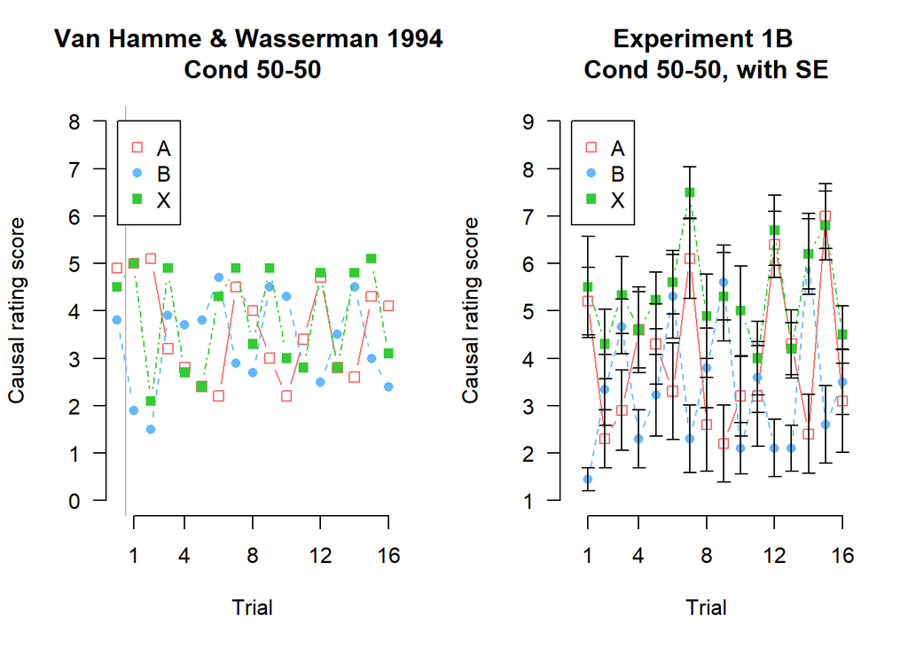

```r
par(mfrow = c(1,2))
par(las=1)
#original plot
emptyPlot(c(0,16),c(0,8), xmark = c(1,4,8,12,16), ymark=c(0,1,2,3,4,5,6,7,8), bty='n', main = "Van Hamme & Wasserman 1994 \nCond 50-50", xlab = "Trial", ylab = "Causal rating score")
A <- c(4.9, 5, 5.1, 3.2, 2.8, 2.4, 2.2, 4.5, 4, 3, 2.2, 3.4, 4.7, 2.8, 2.6, 4.3, 4.1)
B <- c(3.8, 1.9, 1.5, 3.9, 3.7, 3.8, 4.7, 2.9, 2.7, 4.5, 4.3, 2.8, 2.5, 3.5, 4.5, 3, 2.4)
X <- c(4.5, 5, 2.1, 4.9, 2.7, 2.4, 4.3, 4.9, 3.3, 4.9, 3, 2.8, 4.8,2.8, 4.8, 5.1, 3.1)
points(c(0:16),A, pch = 0, type = "b", col = "indianred1")
points(c(0:16),B, pch =16, type = "b", lty = 2, col = "steelblue1")
points(c(0:16),X, pch =15, type = "b", lty = 4, col = "limegreen")
abline(v=0.5, col="grey", lty = 1)
legend(0.05,8,legend =c("A", "B", "X"), pch = c(0,16,15), col = c("indianred1", "steelblue1", "limegreen"))

emptyPlot(c(0,16),c(1,9), xmark = c(1,4,8,12,16), ymark=c(1,2,3,4,5,6,7,8, 9), bty='n', main = "Experiment 1B \nCond 50-50, with SE", xlab = "Trial", ylab = "Causal rating score")
A <- Cond000$A
B <- Cond000$B
X <- Cond000$X
points(c(1:16),A, pch = 0, type = "b", col = "indianred1")
points(c(1:16),B, pch =16, type = "b", lty = 2, col = "steelblue1")
points(c(1:16),X, pch =15, type = "b", lty = 4, col = "limegreen")
errorbars(x= c(1:16), y = Cond000$A, top = SETrials000A, bottom = SETrials000A, add = TRUE, length = 0.05)
errorbars(x= c(1:16), y = Cond000$B, top = SETrials000B, bottom = SETrials000B, add = TRUE, length = 0.05)
errorbars(x= c(1:16), y = Cond000$X, top = SETrials000X, bottom = SETrials000X, add = TRUE, length = 0.05)
legend(0.05,9,legend =c("A", "B", "X"), pch = c(0,16,15), col = c("indianred1", "steelblue1", "limegreen"))
```

## Cond 050

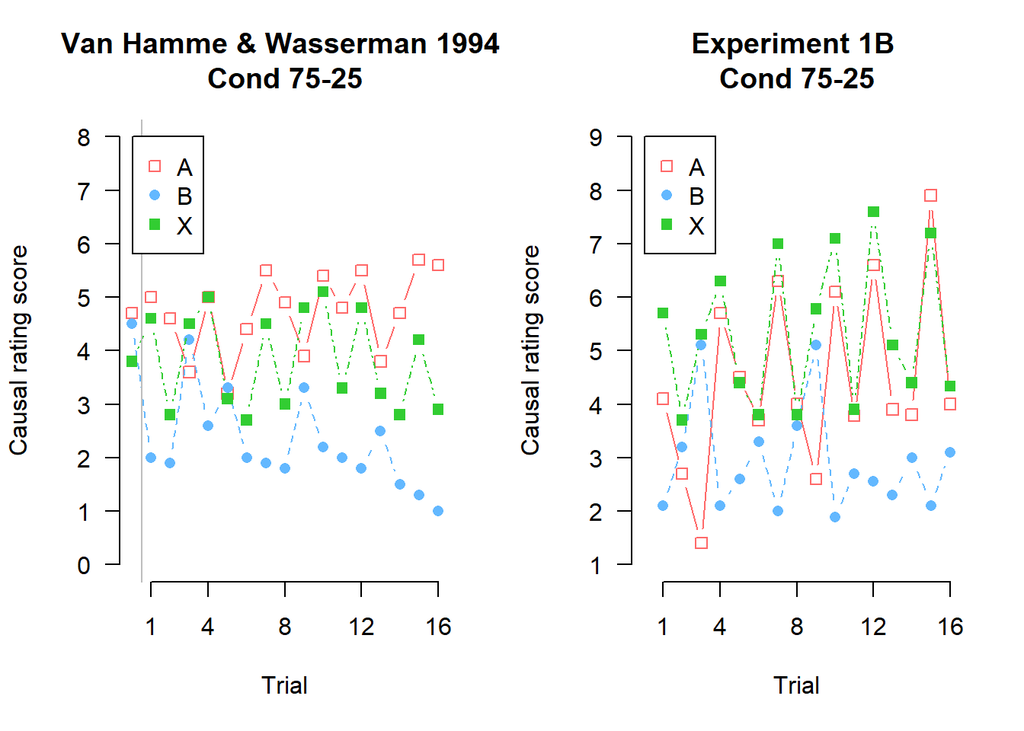

```r
par(mfrow = c(1,2))
par(las=1)
#original plot
emptyPlot(c(0,16),c(0,8), xmark = c(1,4,8,12,16), ymark=c(0,1,2,3,4,5,6,7,8), bty='n', main = "Van Hamme & Wasserman 1994 \nCond 75-25", xlab = "Trial", ylab = "Causal rating score")
A <- c(4.7,5,4.6,3.6,5,3.2,4.4,5.5,4.9,3.9,5.4,4.8,5.5,3.8,4.7,5.7,5.6)
B <- c(4.5,2,1.9,4.2,2.6,3.3,2,1.9,1.8,3.3,2.2,2,1.8,2.5,1.5,1.3,1)
X <- c(3.8,4.6,2.8,4.5,5,3.1,2.7,4.5,3,4.8,5.1,3.3,4.8,3.2,2.8,4.2,2.9)
points(c(0:16),A, pch = 0, type = "b", col = "indianred1")
points(c(0:16),B, pch =16, type = "b", lty = 2, col = "steelblue1")
points(c(0:16),X, pch =15, type = "b", lty = 4, col = "limegreen")
abline(v=0.5, col="grey", lty = 1)
legend(0.05,8,legend =c("A", "B", "X"), pch = c(0,16,15), col = c("indianred1", "steelblue1", "limegreen"))

emptyPlot(c(0,16),c(1,9), xmark = c(1,4,8,12,16), ymark=c(1,2,3,4,5,6,7,8, 9), bty='n', main = "Experiment 1B \nCond 75-25", xlab = "Trial", ylab = "Causal rating score")
A <- Cond050$A
B <- Cond050$B
X <- Cond050$X
points(c(1:16),A, pch = 0, type = "b", col = "indianred1")
points(c(1:16),B, pch =16, type = "b", lty = 2, col = "steelblue1")
points(c(1:16),X, pch =15, type = "b", lty = 4, col = "limegreen")
legend(0.05,9,legend =c("A", "B", "X"), pch = c(0,16,15), col = c("indianred1", "steelblue1", "limegreen"))
```

## Cond 050 Thicker lines

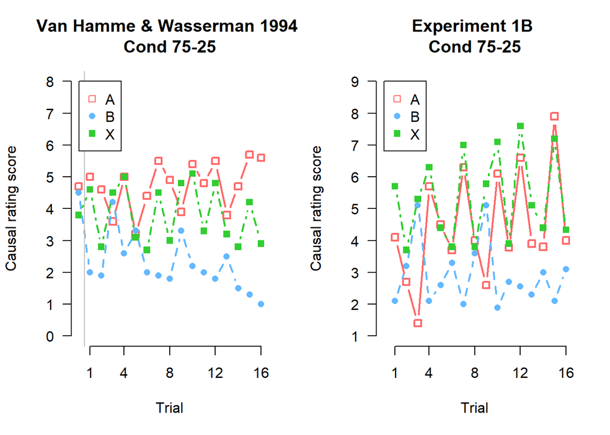

```r
par(mfrow = c(1,2))
par(las=1)
#original plot
emptyPlot(c(0,16),c(0,8), xmark = c(1,4,8,12,16), ymark=c(0,1,2,3,4,5,6,7,8), bty='n', main = "Van Hamme & Wasserman 1994 \nCond 75-25", xlab = "Trial", ylab = "Causal rating score")
A <- c(4.7,5,4.6,3.6,5,3.2,4.4,5.5,4.9,3.9,5.4,4.8,5.5,3.8,4.7,5.7,5.6)
B <- c(4.5,2,1.9,4.2,2.6,3.3,2,1.9,1.8,3.3,2.2,2,1.8,2.5,1.5,1.3,1)
X <- c(3.8,4.6,2.8,4.5,5,3.1,2.7,4.5,3,4.8,5.1,3.3,4.8,3.2,2.8,4.2,2.9)
points(c(0:16),A, pch = 0, type = "b", col = "indianred1", lwd = 2)
points(c(0:16),B, pch =16, type = "b", lty = 2, col = "steelblue1", lwd =2)
points(c(0:16),X, pch =15, type = "b", lty = 4, col = "limegreen", lwd = 2)
abline(v=0.5, col="grey", lty = 1)
legend(0.05,8,legend =c("A", "B", "X"), pch = c(0,16,15), col = c("indianred1", "steelblue1", "limegreen"))

emptyPlot(c(0,16),c(1,9), xmark = c(1,4,8,12,16), ymark=c(1,2,3,4,5,6,7,8, 9), bty='n', main = "Experiment 1B \nCond 75-25", xlab = "Trial", ylab = "Causal rating score")
A <- Cond050$A
B <- Cond050$B
X <- Cond050$X
points(c(1:16),A, pch = 0, type = "b", col = "indianred1", lwd = 2)
points(c(1:16),B, pch =16, type = "b", lty = 2, col = "steelblue1", lwd =2)
points(c(1:16),X, pch =15, type = "b", lty = 4, col = "limegreen", lwd =2)
legend(0.05,9,legend =c("A", "B", "X"), pch = c(0,16,15), col = c("indianred1", "steelblue1", "limegreen"))
```

## Cond 050

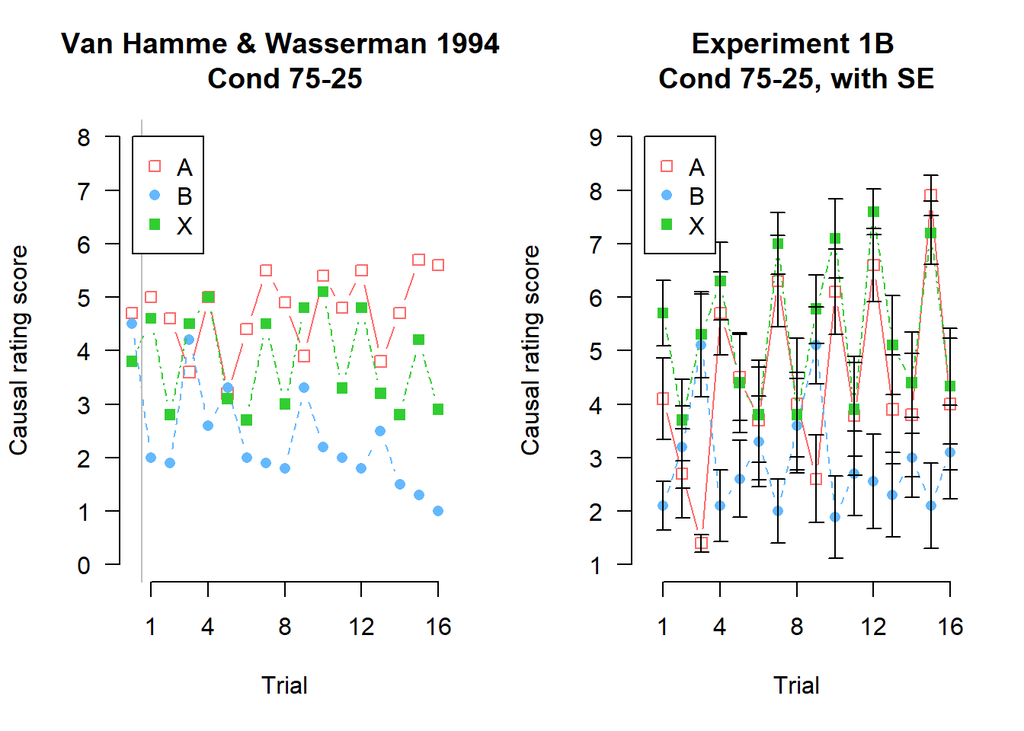

```r
par(mfrow = c(1,2))
par(las=1)
#original plot
emptyPlot(c(0,16),c(0,8), xmark = c(1,4,8,12,16), ymark=c(0,1,2,3,4,5,6,7,8), bty='n', main = "Van Hamme & Wasserman 1994 \nCond 75-25", xlab = "Trial", ylab = "Causal rating score")
A <- c(4.7,5,4.6,3.6,5,3.2,4.4,5.5,4.9,3.9,5.4,4.8,5.5,3.8,4.7,5.7,5.6)
B <- c(4.5,2,1.9,4.2,2.6,3.3,2,1.9,1.8,3.3,2.2,2,1.8,2.5,1.5,1.3,1)
X <- c(3.8,4.6,2.8,4.5,5,3.1,2.7,4.5,3,4.8,5.1,3.3,4.8,3.2,2.8,4.2,2.9)
points(c(0:16),A, pch = 0, type = "b", col = "indianred1")
points(c(0:16),B, pch =16, type = "b", lty = 2, col = "steelblue1")
points(c(0:16),X, pch =15, type = "b", lty = 4, col = "limegreen")
abline(v=0.5, col="grey", lty = 1)
legend(0.05,8,legend =c("A", "B", "X"), pch = c(0,16,15), col = c("indianred1", "steelblue1", "limegreen"))

emptyPlot(c(0,16),c(1,9), xmark = c(1,4,8,12,16), ymark=c(1,2,3,4,5,6,7,8, 9), bty='n', main = "Experiment 1B \nCond 75-25, with SE", xlab = "Trial", ylab = "Causal rating score")
A <- Cond050$A
B <- Cond050$B
X <- Cond050$X
points(c(1:16),A, pch = 0, type = "b", col = "indianred1")
points(c(1:16),B, pch =16, type = "b", lty = 2, col = "steelblue1")
points(c(1:16),X, pch =15, type = "b", lty = 4, col = "limegreen")
errorbars(x= c(1:16), y = Cond050$A, top = SETrials050A, bottom = SETrials050A, add = TRUE, length = 0.05)
errorbars(x= c(1:16), y = Cond050$B, top = SETrials050B, bottom = SETrials050B, add = TRUE, length = 0.05)
errorbars(x= c(1:16), y = Cond050$X, top = SETrials050X, bottom = SETrials050X, add = TRUE, length = 0.05)
legend(0.05,9,legend =c("A", "B", "X"), pch = c(0,16,15), col = c("indianred1", "steelblue1", "limegreen"))
```

## Cond 100

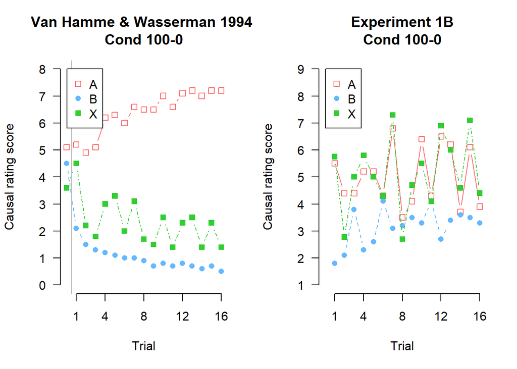

```r
par(mfrow = c(1,2))
par(las=1)
#original plot
emptyPlot(c(0,16),c(0,8), xmark = c(1,4,8,12,16), ymark=c(0,1,2,3,4,5,6,7,8), bty='n', main = "Van Hamme & Wasserman 1994 \nCond 100-0", xlab = "Trial", ylab = "Causal rating score")
A <- c(5.1,5.2,4.9,5.1,6.2,6.3,6,6.6,6.5,6.5,7,6.6,7.1,7.2,7,7.2,7.2)
B <- c(4.5,2.1,1.5,1.3,1.2,1.1,1,1,0.9,0.7,0.8,0.7,0.8,0.7,0.6,0.7,0.5)
X <- c(3.6,4.5,2.2,1.8,3,3.3,2,3.1,1.7,1.5,2.5,1.4,2.3,2.5,1.4,2.3,1.4)
points(c(0:16),A, pch = 0, type = "b", col = "indianred1")
points(c(0:16),B, pch =16, type = "b", lty = 2, col = "steelblue1")
points(c(0:16),X, pch =15, type = "b", lty = 4, col = "limegreen")
abline(v=0.5, col="grey", lty = 1)
legend(0.05,8,legend =c("A", "B", "X"), pch = c(0,16,15), col = c("indianred1", "steelblue1", "limegreen"))

emptyPlot(c(0,16),c(1,9), xmark = c(1,4,8,12,16), ymark=c(1,2,3,4,5,6,7,8, 9), bty='n', main = "Experiment 1B\nCond 100-0", xlab = "Trial", ylab = "Causal rating score")
A <- Cond100$A
B <- Cond100$B
X <- Cond100$X
points(c(1:16),A, pch = 0, type = "b", col = "indianred1")
points(c(1:16),B, pch =16, type = "b", lty = 2, col = "steelblue1")
points(c(1:16),X, pch =15, type = "b", lty = 4, col = "limegreen")

legend(0.05,9,legend =c("A", "B", "X"), pch = c(0,16,15), col = c("indianred1", "steelblue1", "limegreen"))
```

## Cond 100 Thicker lines

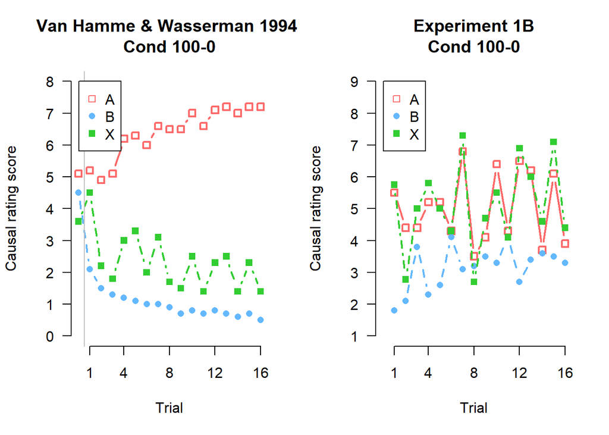

```r
par(mfrow = c(1,2))
par(las=1)
#original plot
emptyPlot(c(0,16),c(0,8), xmark = c(1,4,8,12,16), ymark=c(0,1,2,3,4,5,6,7,8), bty='n', main = "Van Hamme & Wasserman 1994 \nCond 100-0", xlab = "Trial", ylab = "Causal rating score")
A <- c(5.1,5.2,4.9,5.1,6.2,6.3,6,6.6,6.5,6.5,7,6.6,7.1,7.2,7,7.2,7.2)
B <- c(4.5,2.1,1.5,1.3,1.2,1.1,1,1,0.9,0.7,0.8,0.7,0.8,0.7,0.6,0.7,0.5)
X <- c(3.6,4.5,2.2,1.8,3,3.3,2,3.1,1.7,1.5,2.5,1.4,2.3,2.5,1.4,2.3,1.4)
points(c(0:16),A, pch = 0, type = "b", col = "indianred1", lwd = 2)
points(c(0:16),B, pch =16, type = "b", lty = 2, col = "steelblue1", lwd = 2)
points(c(0:16),X, pch =15, type = "b", lty = 4, col = "limegreen", lwd = 2)
abline(v=0.5, col="grey", lty = 1)
legend(0.05,8,legend =c("A", "B", "X"), pch = c(0,16,15), col = c("indianred1", "steelblue1", "limegreen"))

emptyPlot(c(0,16),c(1,9), xmark = c(1,4,8,12,16), ymark=c(1,2,3,4,5,6,7,8, 9), bty='n', main = "Experiment 1B\nCond 100-0", xlab = "Trial", ylab = "Causal rating score")
A <- Cond100$A
B <- Cond100$B
X <- Cond100$X
points(c(1:16),A, pch = 0, type = "b", col = "indianred1", lwd = 2)
points(c(1:16),B, pch =16, type = "b", lty = 2, col = "steelblue1", lwd =2)
points(c(1:16),X, pch =15, type = "b", lty = 4, col = "limegreen", lwd = 2)

legend(0.05,9,legend =c("A", "B", "X"), pch = c(0,16,15), col = c("indianred1", "steelblue1", "limegreen"))
```

## Cond 100

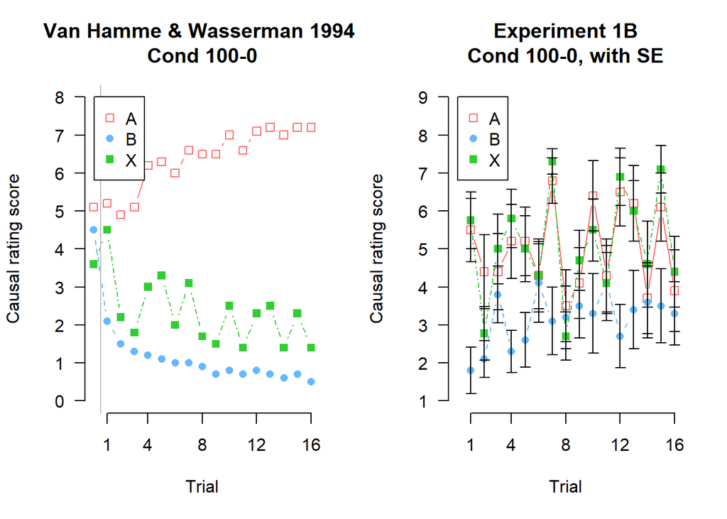

```r
par(mfrow = c(1,2))
par(las=1)
#original plot
emptyPlot(c(0,16),c(0,8), xmark = c(1,4,8,12,16), ymark=c(0,1,2,3,4,5,6,7,8), bty='n', main = "Van Hamme & Wasserman 1994 \nCond 100-0", xlab = "Trial", ylab = "Causal rating score")
A <- c(5.1,5.2,4.9,5.1,6.2,6.3,6,6.6,6.5,6.5,7,6.6,7.1,7.2,7,7.2,7.2)
B <- c(4.5,2.1,1.5,1.3,1.2,1.1,1,1,0.9,0.7,0.8,0.7,0.8,0.7,0.6,0.7,0.5)
X <- c(3.6,4.5,2.2,1.8,3,3.3,2,3.1,1.7,1.5,2.5,1.4,2.3,2.5,1.4,2.3,1.4)
points(c(0:16),A, pch = 0, type = "b", col = "indianred1")
points(c(0:16),B, pch =16, type = "b", lty = 2, col = "steelblue1")
points(c(0:16),X, pch =15, type = "b", lty = 4, col = "limegreen")
abline(v=0.5, col="grey", lty = 1)
legend(0.05,8,legend =c("A", "B", "X"), pch = c(0,16,15), col = c("indianred1", "steelblue1", "limegreen"))

emptyPlot(c(0,16),c(1,9), xmark = c(1,4,8,12,16), ymark=c(1,2,3,4,5,6,7,8, 9), bty='n', main = "Experiment 1B\nCond 100-0, with SE", xlab = "Trial", ylab = "Causal rating score")
A <- Cond100$A
B <- Cond100$B
X <- Cond100$X
points(c(1:16),A, pch = 0, type = "b", col = "indianred1")
points(c(1:16),B, pch =16, type = "b", lty = 2, col = "steelblue1")
points(c(1:16),X, pch =15, type = "b", lty = 4, col = "limegreen")
errorbars(x= c(1:16), y = Cond100$A, top = SETrials100A, bottom = SETrials100A, add = TRUE, length = 0.05)
errorbars(x= c(1:16), y = Cond100$B, top = SETrials100B, bottom = SETrials100B, add = TRUE, length = 0.05)
errorbars(x= c(1:16), y = Cond100$X, top = SETrials100X, bottom = SETrials100X, add = TRUE, length = 0.05)

legend(0.05,9,legend =c("A", "B", "X"), pch = c(0,16,15), col = c("indianred1", "steelblue1", "limegreen"))
```

# Participants

```r
#I'm sampling 3 here
#sample(unique(dat$prolific_id), 3, replace = TRUE)
#"5ffa1ea174ea4b3b304bef6a" "5bc79f652885710001a0e82a" "60021cc6d5be39201d34f6bf"
#so I'll plot those three people
P1 <- subset(train, train$prolific_id == "5ffa1ea174ea4b3b304bef6a")
P2 <- subset(train, train$prolific_id == "5bc79f652885710001a0e82a")
P3 <- subset(train, train$prolific_id == "5ec7ec8d0125920a254a6cfa")
```

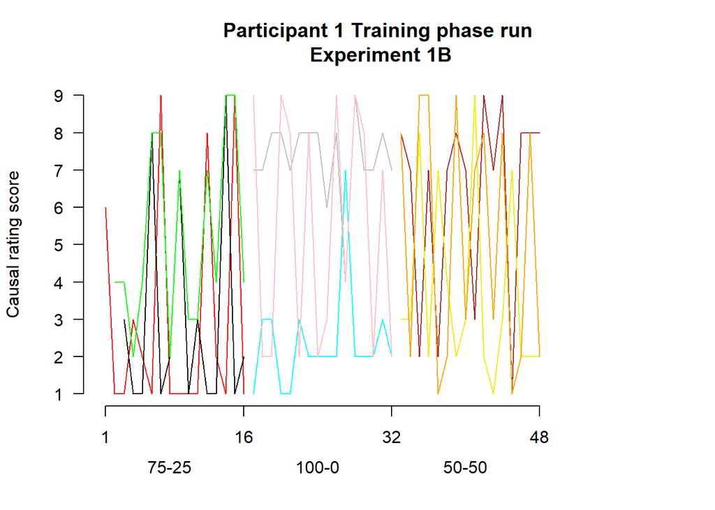

```r
#p1 had Cond 50, 100, 0
par(mfrow = c(1,1))
par(las = 1)
emptyPlot(c(1,60), c(1,9), xmark = c(1,16,32,48), ymark= c(1,2,3,4,5,6,7,8,9), bty = 'n', main = "Participant 1 Training phase run\n Experiment 1B", xlab = "", ylab = "Causal rating score")
points(c(1:16), P1$responseR1[P1$blockNr == "Block1"], type = 'l', col = "red", lty = 1, lwd = 1)
points(c(1:16), P1$responseR2[P1$blockNr == "Block1"], type = 'l', col = "black", lty = 1, lwd = 1)
points(c(1:16), P1$responseR3[P1$blockNr == "Block1"], type = 'l', col = "green", lty = 1, lwd = 1)
points(c(17:32), P1$responseR1[P1$blockNr == "Block2"], type = 'l', col = "grey", lty = 1, lwd = 1)
points(c(17:32), P1$responseR2[P1$blockNr == "Block2"], type = 'l', col = "cyan", lty = 1, lwd = 1)
points(c(17:32), P1$responseR3[P1$blockNr == "Block2"], type = 'l', col = "pink", lty = 1, lwd = 1)
points(c(33:48), P1$responseR1[P1$blockNr == "Block3"], type = 'l', col = "brown", lty = 1, lwd = 1)
points(c(33:48), P1$responseR2[P1$blockNr == "Block3"], type = 'l', col = "yellow2", lty = 1, lwd = 1)
points(c(33:48), P1$responseR3[P1$blockNr == "Block3"], type = 'l', col = "orange", lty = 1, lwd = 1)
mtext("75-25", side = 1, at = 8, line = 2.5)
mtext("100-0", side = 1, at = 24, line = 2.5)
mtext("50-50", side = 1, at = 40, line = 2.5)
```

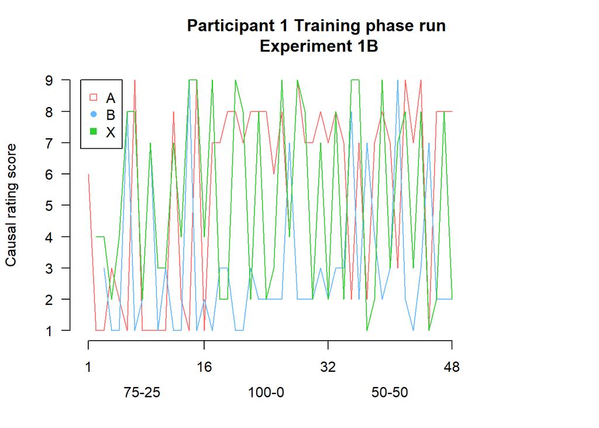

```r
#still P1
par(mfrow = c(1,1))
par(las = 1)
emptyPlot(c(1,60), c(1,9), xmark = c(1,16,32,48), ymark= c(1,2,3,4,5,6,7,8,9), bty = 'n', main = "Participant 1 Training phase run\n Experiment 1B", xlab = "", ylab = "Causal rating score")
points(c(1:48), P1$responseR1, type = 'l', col = "indianred1", lty = 1, lwd = 1)
points(c(1:48), P1$responseR2, type = 'l', col = "steelblue1", lty = 1, lwd = 1)
points(c(1:48), P1$responseR3, type = 'l', col = "limegreen", lty = 1, lwd = 1)
mtext("75-25", side = 1, at = 8, line = 2.5)
mtext("100-0", side = 1, at = 24, line = 2.5)
mtext("50-50", side = 1, at = 40, line = 2.5)
legend(0.02,9,legend =c("A", "B", "X"), pch = c(0,16,15), col = c("indianred1", "steelblue1", "limegreen"))
```

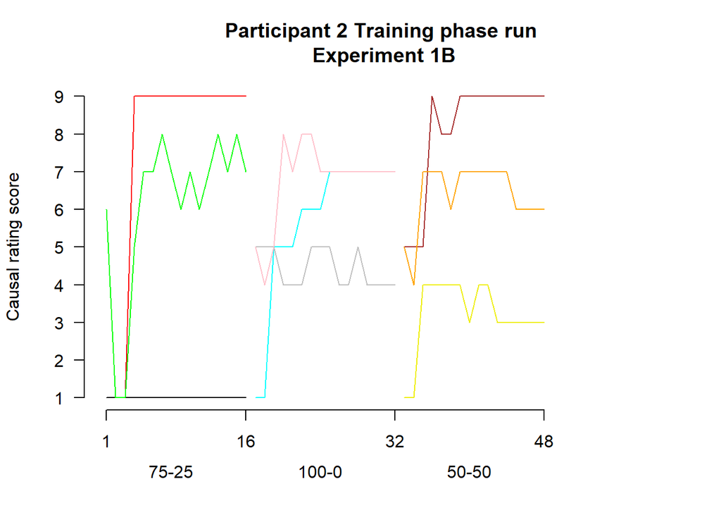

```r
#p2 had Cond 50, 100, 0.
par(mfrow = c(1,1))
par(las = 1)
emptyPlot(c(1,60), c(1,9), xmark = c(1,16,32,48), ymark= c(1,2,3,4,5,6,7,8,9), bty = 'n', main = "Participant 2 Training phase run\n Experiment 1B", xlab = "", ylab = "Causal rating score")
points(c(1:16), P2$responseR1[P2$blockNr == "Block1"], type = 'l', col = "red", lty = 1, lwd = 1)
points(c(1:16), P2$responseR2[P2$blockNr == "Block1"], type = 'l', col = "black", lty = 1, lwd = 1)
points(c(1:16), P2$responseR3[P2$blockNr == "Block1"], type = 'l', col = "green", lty = 1, lwd = 1)
points(c(17:32), P2$responseR1[P2$blockNr == "Block2"], type = 'l', col = "grey", lty = 1, lwd = 1)
points(c(17:32), P2$responseR2[P2$blockNr == "Block2"], type = 'l', col = "cyan", lty = 1, lwd = 1)
points(c(17:32), P2$responseR3[P2$blockNr == "Block2"], type = 'l', col = "pink", lty = 1, lwd = 1)
points(c(33:48), P2$responseR1[P2$blockNr == "Block3"], type = 'l', col = "brown", lty = 1, lwd = 1)
points(c(33:48), P2$responseR2[P2$blockNr == "Block3"], type = 'l', col = "yellow2", lty = 1, lwd = 1)
points(c(33:48), P2$responseR3[P2$blockNr == "Block3"], type = 'l', col = "orange", lty = 1, lwd = 1)
mtext("75-25", side = 1, at = 8, line = 2.5)
mtext("100-0", side = 1, at = 24, line = 2.5)
mtext("50-50", side = 1, at = 40, line = 2.5)
```

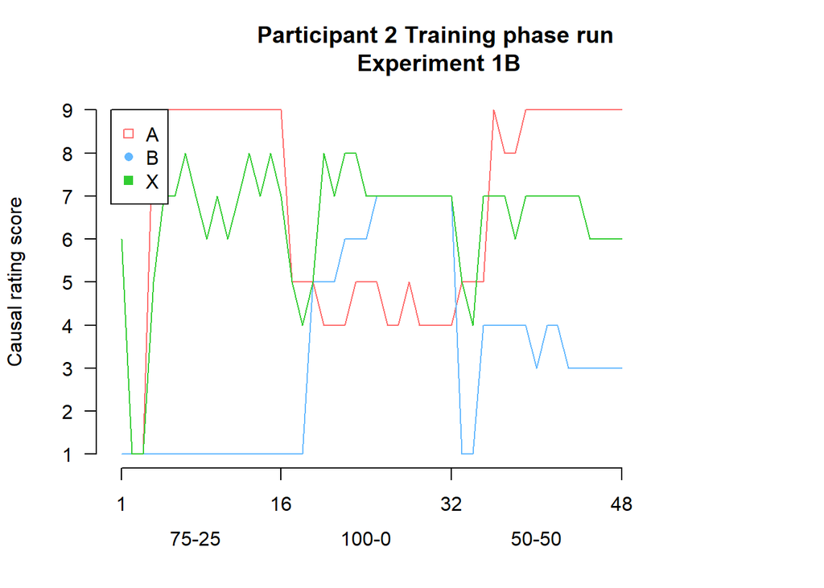

```r
#still P2
par(mfrow = c(1,1))
par(las = 1)
emptyPlot(c(1,60), c(1,9), xmark = c(1,16,32,48), ymark= c(1,2,3,4,5,6,7,8,9), bty = 'n', main = "Participant 2 Training phase run\n Experiment 1B", xlab = "", ylab = "Causal rating score")
points(c(1:48), P2$responseR1, type = 'l', col = "indianred1", lty = 1, lwd = 1)
points(c(1:48), P2$responseR2, type = 'l', col = "steelblue1", lty = 1, lwd = 1)
points(c(1:48), P2$responseR3, type = 'l', col = "limegreen", lty = 1, lwd = 1)
mtext("75-25", side = 1, at = 8, line = 2.5)
mtext("100-0", side = 1, at = 24, line = 2.5)
mtext("50-50", side = 1, at = 40, line = 2.5)
legend(0.02,9,legend =c("A", "B", "X"), pch = c(0,16,15), col = c("indianred1", "steelblue1", "limegreen"))
```

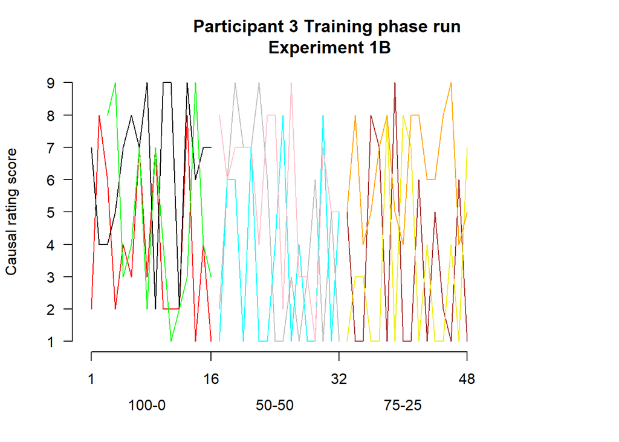

```r
#p3 had Cond 100, 0, 50.
par(mfrow = c(1,1))
par(las = 1)
emptyPlot(c(1,60), c(1,9), xmark = c(1,16,32,48), ymark= c(1,2,3,4,5,6,7,8,9), bty = 'n', main = "Participant 3 Training phase run\n Experiment 1B", xlab = "", ylab = "Causal rating score")
points(c(1:16), P3$responseR1[P3$blockNr == "Block1"], type = 'l', col = "red", lty = 1, lwd = 1)
points(c(1:16), P3$responseR2[P3$blockNr == "Block1"], type = 'l', col = "black", lty = 1, lwd = 1)
points(c(1:16), P3$responseR3[P3$blockNr == "Block1"], type = 'l', col = "green", lty = 1, lwd = 1)
points(c(17:32), P3$responseR1[P3$blockNr == "Block2"], type = 'l', col = "grey", lty = 1, lwd = 1)
points(c(17:32), P3$responseR2[P3$blockNr == "Block2"], type = 'l', col = "cyan", lty = 1, lwd = 1)
points(c(17:32), P3$responseR3[P3$blockNr == "Block2"], type = 'l', col = "pink", lty = 1, lwd = 1)
points(c(33:48), P3$responseR1[P3$blockNr == "Block3"], type = 'l', col = "brown", lty = 1, lwd = 1)
points(c(33:48), P3$responseR2[P3$blockNr == "Block3"], type = 'l', col = "yellow2", lty = 1, lwd = 1)
points(c(33:48), P3$responseR3[P3$blockNr == "Block3"], type = 'l', col = "orange", lty = 1, lwd = 1)
mtext("100-0", side = 1, at = 8, line = 2.5)
mtext("50-50", side = 1, at = 24, line = 2.5)
mtext("75-25", side = 1, at = 40, line = 2.5)
```

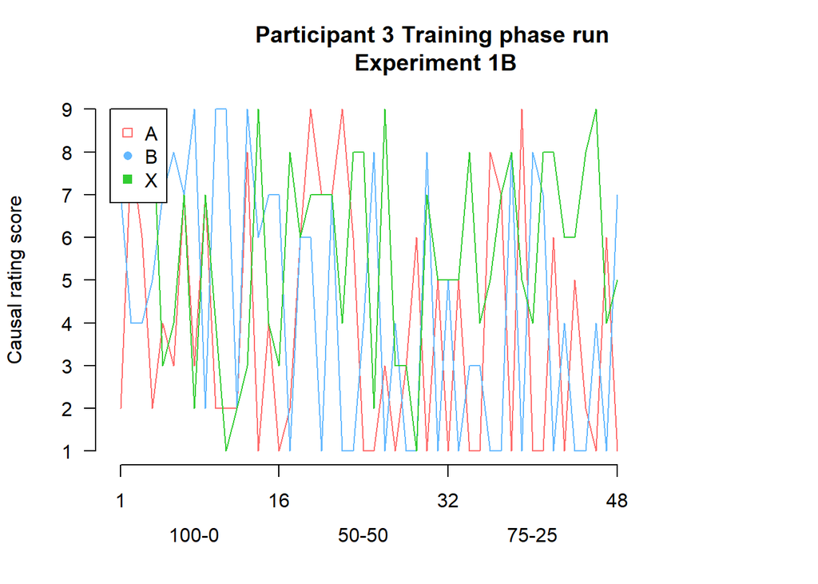

```r
#still P3
par(mfrow = c(1,1))
par(las = 1)
emptyPlot(c(1,60), c(1,9), xmark = c(1,16,32,48), ymark= c(1,2,3,4,5,6,7,8,9), bty = 'n', main = "Participant 3 Training phase run\n Experiment 1B", xlab = "", ylab = "Causal rating score")
points(c(1:48), P3$responseR1, type = 'l', col = "indianred1", lty = 1, lwd = 1)
points(c(1:48), P3$responseR2, type = 'l', col = "steelblue1", lty = 1, lwd = 1)
points(c(1:48), P3$responseR3, type = 'l', col = "limegreen", lty = 1, lwd = 1)
mtext("100-0", side = 1, at = 8, line = 2.5)
mtext("50-50", side = 1, at = 24, line = 2.5)
mtext("75-25", side = 1, at = 40, line = 2.5)
legend(0.02,9,legend =c("A", "B", "X"), pch = c(0,16,15), col = c("indianred1", "steelblue1", "limegreen"))
```

# Diamond vs no diamond

```r
#Calculating the average scores on the trials where "Diamond" was the outcome, and on trials where "No Diamond" was the outcome
#We would expect that the scores to the No Diamond would be lower on average
Diamond <- subset(train, train$Outcome == "Diamond.png")
NoDiamond <- subset(train, train$Outcome == "NoDiamond.png")

DiamondAvg <- aggregate(list(Diamond$responseR1, Diamond$responseR2, Diamond$responseR3), list(Diamond$Cond), mean, na.rm = T)
NoDiamondAvg <- aggregate(list(NoDiamond$responseR1, NoDiamond$responseR2, NoDiamond$responseR3), list(NoDiamond$Cond), mean, na.rm = T)
SE <- c(std.error(Diamond$responseR1[Diamond$Cond == "0"]), std.error(NoDiamond$responseR1[NoDiamond$Cond == "0"]), std.error(Diamond$responseR2[Diamond$Cond == "0"]), std.error(NoDiamond$responseR2[NoDiamond$Cond == "0"]), std.error(Diamond$responseR3[Diamond$Cond == "0"]), std.error(NoDiamond$responseR3[NoDiamond$Cond == "0"]),  std.error(Diamond$responseR1[Diamond$Cond == "50"]), std.error(NoDiamond$responseR1[NoDiamond$Cond == "50"]), std.error(Diamond$responseR2[Diamond$Cond == "50"]), std.error(NoDiamond$responseR2[NoDiamond$Cond == "50"]), std.error(Diamond$responseR3[Diamond$Cond == "50"]), std.error(NoDiamond$responseR3[NoDiamond$Cond == "50"]),  std.error(Diamond$responseR1[Diamond$Cond == "100"]), std.error(NoDiamond$responseR1[NoDiamond$Cond == "100"]), std.error(Diamond$responseR2[Diamond$Cond == "100"]), std.error(NoDiamond$responseR2[NoDiamond$Cond == "100"]), std.error(Diamond$responseR3[Diamond$Cond == "100"]), std.error(NoDiamond$responseR3[NoDiamond$Cond == "100"]))
colnames(DiamondAvg) <- c("Cond", "A", "B", "X")
colnames(NoDiamondAvg) <- c("Cond", "A", "B", "X")

DiamondAvg
```

```
##   Cond      A        B        X
## 1    0 4.8625 3.571429 6.526316
## 2   50 5.1750 2.961538 6.871795
## 3  100 6.0250 3.125000 6.717949
```

```r
NoDiamondAvg
```

```
##   Cond        A       B        X
## 1    0 3.025000 3.21519 4.217949
## 2   50 3.708861 2.90000 3.810127
## 3  100 4.037500 3.17500 3.556962
```

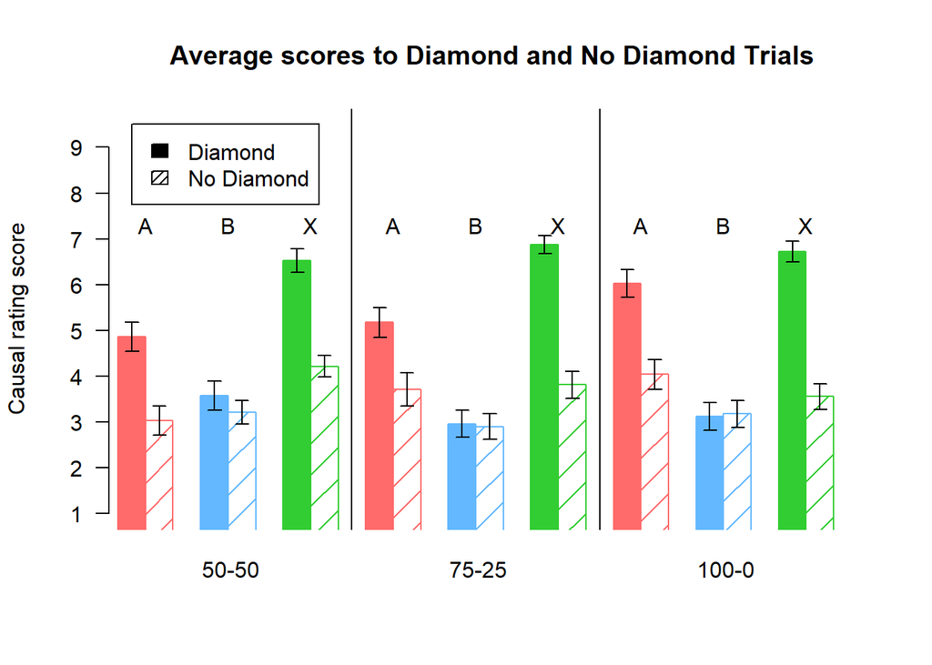

```r
par(mfrow = c(1,1))
par(las = 1)
emptyPlot(c(1,130), c(1,9.5), xaxt = "none", ymark= c(1,2,3,4,5,6, 7, 8,9), bty = 'n', main = "Average scores to Diamond and No Diamond Trials", xlab = "", ylab = "Causal rating score")
add_bars(x=c(0,5,15,20,30,35, 45,50,60,65,75,80, 90,95,105,110,120,125), y=c(DiamondAvg$A[DiamondAvg$Cond == "0"], NoDiamondAvg$A[NoDiamondAvg$Cond == "0"], DiamondAvg$B[DiamondAvg$Cond == "0"], NoDiamondAvg$B[NoDiamondAvg$Cond == "0"],DiamondAvg$X[DiamondAvg$Cond == "0"], NoDiamondAvg$X[NoDiamondAvg$Cond == "0"], DiamondAvg$A[DiamondAvg$Cond == "50"], NoDiamondAvg$A[NoDiamondAvg$Cond == "50"], DiamondAvg$B[DiamondAvg$Cond == "50"], NoDiamondAvg$B[NoDiamondAvg$Cond == "50"],DiamondAvg$X[DiamondAvg$Cond == "50"], NoDiamondAvg$X[NoDiamondAvg$Cond == "50"], DiamondAvg$A[DiamondAvg$Cond == "100"], NoDiamondAvg$A[NoDiamondAvg$Cond == "100"], DiamondAvg$B[DiamondAvg$Cond == "100"], NoDiamondAvg$B[NoDiamondAvg$Cond == "100"],DiamondAvg$X[DiamondAvg$Cond == "100"], NoDiamondAvg$X[NoDiamondAvg$Cond == "100"]), width = 5, col = c("indianred1", "indianred1", "steelblue1", "steelblue1", "limegreen", "limegreen"), density = c(200,6))

errorbars(x=c(0,5,15,20,30,35, 45,50,60,65,75,80, 90,95,105,110,120,125), y=c(DiamondAvg$A[DiamondAvg$Cond == "0"], NoDiamondAvg$A[NoDiamondAvg$Cond == "0"], DiamondAvg$B[DiamondAvg$Cond == "0"], NoDiamondAvg$B[NoDiamondAvg$Cond == "0"],DiamondAvg$X[DiamondAvg$Cond == "0"], NoDiamondAvg$X[NoDiamondAvg$Cond == "0"], DiamondAvg$A[DiamondAvg$Cond == "50"], NoDiamondAvg$A[NoDiamondAvg$Cond == "50"], DiamondAvg$B[DiamondAvg$Cond == "50"], NoDiamondAvg$B[NoDiamondAvg$Cond == "50"],DiamondAvg$X[DiamondAvg$Cond == "50"], NoDiamondAvg$X[NoDiamondAvg$Cond == "50"], DiamondAvg$A[DiamondAvg$Cond == "100"], NoDiamondAvg$A[NoDiamondAvg$Cond == "100"], DiamondAvg$B[DiamondAvg$Cond == "100"], NoDiamondAvg$B[NoDiamondAvg$Cond == "100"],DiamondAvg$X[DiamondAvg$Cond == "100"], NoDiamondAvg$X[NoDiamondAvg$Cond == "100"]) , top = SE , bottom = SE, add = TRUE, length = .05)

abline(v=40, col="grey2", lty = 1)
abline(v=85, col="grey2", lty = 1)
#condition text
mtext("50-50", side = 1, at = 18, line = 1)
mtext("75-25", side = 1, at = 63, line = 1)
mtext("100-0", side = 1, at = 108, line = 1)
#letters
text(x=2.5, y = 7.3, labels = "A")
text(x=47.5, y = 7.3, labels = "A")
text(x=92.5, y = 7.3, labels = "A")
text(x=17.5, y = 7.3, labels = "B")
text(x=62.5, y = 7.3, labels = "B")
text(x=107.5, y = 7.3, labels = "B")
text(x=32.5, y = 7.3, labels = "X")
text(x=77.5, y = 7.3, labels = "X")
text(x=122.5, y = 7.3, labels = "X")
legend(x=0, y = 9.5, legend =c("Diamond", "No Diamond"), density = c(200,20), col= c("indianred1"))
```

```r
#c("indianred1", "indianred3", "steelblue1", "steelblue3", "limegreen", "palegreen4"))

SE
```

```
##  [1] 0.3175977 0.3172144 0.3145093 0.2558443 0.2557916 0.2397742 0.3279081
##  [8] 0.3635234 0.2927941 0.2742077 0.2001988 0.2922098 0.3024033 0.3287124
## [15] 0.3026126 0.2910995 0.2241627 0.2806926
```

```r
range(SE)
```

```
## [1] 0.2001988 0.3635234
```

## Diamond and Fossils

This one needs to be updated!!

```r
# SE_FD <- c(std.error(A1D$responseR1), std.error(A1F$responseR1),std.error(B1D$responseR1), std.error(B1F$responseR1), std.error(X1D$responseR2), std.error(X1F$responseR2), std.error(CD$responseR1), std.error(CF$responseR1), std.error(A3D$responseR1), std.error(A3F$responseR1),std.error(B3D$responseR1), std.error(B3F$responseR1), std.error(X3D$responseR2), std.error(X3F$responseR2))
#
# par(mfrow = c(1,1))
# par(las = 1)
# emptyPlot(c(1,100), c(1,9), xaxt = "none", ymark= c(1,2,3,4,5,6,7,8,9), bty = 'n', main = "Average scores to Diamond and Fossil trials\n in test phase 1", xlab = "", ylab = "Causal rating score")
# add_bars(x=c(0,5,15,20,30,35,45,50,60,65,75,80,90,95), y=c(avgA1D, avgA1F, avgA1D, avgB1F, avgX1D, avgX1F, avgCD, avgCF, avgA3D, avgA3F, avgB3D, avgB3F, avgX3D, avgX3F), width = 5, col = c("indianred1", "indianred1", "steelblue1", "steelblue1", "limegreen", "limegreen","gold", "gold", "indianred1", "indianred1", "steelblue1", "steelblue1", "limegreen", "limegreen"), density = c(200,6))
#
# errorbars(x=c(0,5,15,20,30,35,45,50,60,65,75,80,90,95), y=c(avgA1D, avgA1F, avgA1D, avgB1F, avgX1D, avgX1F, avgCD, avgCF, avgA3D, avgA3F, avgB3D, avgB3F, avgX3D, avgX3F) , top = SE_FD , bottom = SE_FD, add = TRUE, length = .05)
#
# abline(v=40, col="grey2", lty = 1)
# abline(v=55, col="grey2", lty = 1)
# #condition text
# mtext("Cues from block 1", side = 1, at = 17, line = 1)
# mtext("New cue", side = 1, at = 47, line = 1)
# mtext("Cues from block 3", side = 1, at = 77, line = 1)
# #letters
# text(x=2.5, y = 8, labels = "A")
# text(x=17.5, y = 8, labels = "B")
# text(x=32.5, y = 8, labels = "X")
# text(x=47.5, y = 8, labels = "C")
# text(x=62.5, y = 8, labels = "A")
# text(x=77.5, y = 8, labels = "B")
# text(x=92.5, y = 8, labels = "X")
# legend(x=0, y = 7, legend =c("Diamond", "Fossil"), density = c(200,20))
```